# TIMES HCC case study - posteriorHCA healthy-proximity proxy

Can distance from healthy liver NK recover recurrence biology?

Author

Affiliation

Chen Zhan

SAiGENCI, The University of Adelaide

Published

25 Jun 2026

Abstract

This case study evaluates whether posteriorHCA can replace a direct recurrence-trained comparator with a universal healthy reference. We define an outcome-free healthy-proximity score from the absolute standardized distance between HCC NK-enriched expression and the comprehensive healthy liver NK grand-mean posterior. The proxy hypothesis is that non-REC HCC remains healthy-like while REC HCC is more atlas-discordant in both invasive front (IF) and tumour centre (TC). Direct edgeR non-REC versus REC contrasts are retained as a positive control, and the paper’s TIMES validation scores provide a descriptive benchmark. The available GeoMx subset is very small, so this is proof of concept rather than an equivalence-power claim.

# Introduction

Jia *et al.* (2025) built the TIMES score from spatial biomarker expression in both the **invasive front (IF)** and **tumour centre (TC)** to predict recurrence after HCC resection. The original claim is prognostic **within HCC**: non-recurrent (non-REC) versus recurrent (REC) disease. Healthy tissue is not part of the TIMES training contrast or its published ground truth.

The case-study hierarchy is:

| Role | Question | Interpretation |
| --- | --- | --- |
| **Primary posteriorHCA proxy** | Is REC farther from healthy liver NK than non-REC in IF and TC? | Tests whether a universal healthy reference can recover recurrence ordering without training on recurrence |
| **Positive control** | Is each biomarker higher in non-REC than REC within IF and TC? | Confirms that the available GeoMx subset retains the paper’s expression direction |
| **Paper benchmark** | How does proxy discrimination compare descriptively with the supplied TIMES validation scores? | Assesses promise, not formal equivalence, because cohorts and modalities differ |

The proxy is deliberately simple and outcome-free. For patient or cohort (i) and gene (g), healthy distance is

$$D_{ig} =
\frac{\left|\log\mu_{ig} - E(\log\mu_{g,\mathrm{healthy}})\right|}
{SD(\log\mu_{g,\mathrm{healthy}})}.$$

The multi-gene proxy score is the mean (D_{ig}) across atlas-covered TIMES genes. Higher values indicate greater departure from healthy liver NK. The case-study prediction is **REC distance > non-REC distance**. This prediction is not stated in the original paper and must ultimately be validated in an independent cohort.

The appropriate atlas tissue is **healthy liver NK**, not blood NK. The `V1_nk` model includes `tissue_groups = "liver"`. This reference is used as the fixed origin of the proxy; recurrence labels are used only after scoring, for evaluation.

The statistical workflow below now matches SAVI: patient pseudobulk, TMMwsp offsets anchored to the atlas training reference, edgeR NB group means, QL Wald standard errors, Welch tests and empirical posterior ranks. The remaining data limitation is upstream: the public CodeOcean matrix contains author-processed GeoMx transcript-read-like values. We follow the paper capsule and round them before count modelling, but controlled-access raw GeoMx counts remain preferable for a final analysis.

# Library setup

```r
suppressPackageStartupMessages({
  library(tibble)
  library(tidyr)
  library(dplyr)
  library(readr)
  library(purrr)
  library(ggplot2)
  library(forcats)
  library(glue)
  library(stringr)
  library(scales)
  library(targets)
  library(brms)
  library(posterior)
  library(edgeR)
  library(SummarizedExperiment)
  library(S4Vectors)
  library(AnnotationDbi)
  library(org.Hs.eg.db)
})

theme_set(theme_minimal(base_size = 11))

data_dir <- file.path(params$case_dir, "data")
processed_dir <- file.path(data_dir, "processed")
dir.create(processed_dir, recursive = TRUE, showWarnings = FALSE)

target_compartments <- unlist(params$compartments)
```

# TIMES biomarkers and NK model coverage

```r
times_biomarkers <- readr::read_csv(
  file.path(data_dir, "times_biomarkers.csv"),
  show_col_types = FALSE
) |>
  dplyr::select(gene, role, selection_step, notes, .feature)

times_biomarkers
```

| gene | role | selection_step | notes | .feature |
| --- | --- | --- | --- | --- |
| SPON2 | TIMES biomarker (primary) | Top-5 from 23 NK DEGs | Most predictive in XGBoost; NK migration/IFN-gamma; mouse NK-specific knockout validated | ENSG00000159674 |
| ZFP36L2 | TIMES biomarker | Top-5 from 23 NK DEGs | RNA-binding protein; part of inverse-variance weighted TIMES score | ENSG00000152518 |
| ZFP36 | TIMES biomarker | Top-5 from 23 NK DEGs | Also known as TTP; mRNA destabilisation; part of TIMES score | ENSG00000128016 |
| VIM | TIMES biomarker | Top-5 from 23 NK DEGs | Vimentin; mesenchymal/NK activation-associated in spatial mIHC | ENSG00000026025 |
| HLA-DRB1 | TIMES biomarker | Top-5 from 23 NK DEGs | MHC class II; antigen presentation in NK-enriched spatial ROIs | ENSG00000196126 |

```r
model_path <- file.path(
  params$model_store_root,
  paste0("V1_", params$target_cell_type)
)

if (!dir.exists(file.path(model_path, "_targets"))) {
  stop("Missing targets store: ", file.path(model_path, "_targets"))
}

model_meta <- targets::tar_meta(
  starts_with("estimates_chunk_"),
  store = file.path(model_path, "_targets")
) |>
  dplyr::filter(.data$type == "branch") |>
  dplyr::mutate(
    .feature = stringr::str_extract(
      .data$warnings,
      "(?<=Gene:___)ENSG\\d+(?=___)"
    )
  )

biomarker_model_status <- times_biomarkers |>
  dplyr::mutate(
    in_v1_nk_store = !is.na(.data$.feature) & .data$.feature %in% model_meta$.feature,
    target_name = purrr::map_chr(.data$.feature, function(feature_id) {
      hit <- model_meta |>
        dplyr::filter(.data$.feature == feature_id) |>
        dplyr::slice(1) |>
        dplyr::pull(.data$name)
      if (length(hit)) hit[[1]] else NA_character_
    })
  )

biomarker_model_status |>
  dplyr::select(gene, .feature, in_v1_nk_store, target_name)
```

| gene | .feature | in_v1_nk_store | target_name |
| --- | --- | --- | --- |
| SPON2 | ENSG00000159674 | TRUE | estimates_chunk_b8770a3ac6bf4d3e |
| ZFP36L2 | ENSG00000152518 | TRUE | estimates_chunk_e6d78bbdb620a444 |
| ZFP36 | ENSG00000128016 | TRUE | estimates_chunk_9e8434f69eebe3b8 |
| VIM | ENSG00000026025 | TRUE | estimates_chunk_8ca636e9e41dac58 |
| HLA-DRB1 | ENSG00000196126 | FALSE | NA |

`HLA-DRB1` is kept in all HCC summaries, but it is excluded from posteriorHCA baseline testing when absent from the `V1_nk` model store.

```r
example_target <- biomarker_model_status |>
  dplyr::filter(.data$in_v1_nk_store) |>
  dplyr::slice(1) |>
  dplyr::pull(.data$target_name)

example_fit <- targets::tar_read_raw(
  example_target[[1]],
  store = file.path(model_path, "_targets")
)$brms_fit[[1]]

tissue_reference_check <- tibble::tibble(
  requested_baseline_tissue = params$baseline_tissue_group,
  tissue_level_available = params$baseline_tissue_group %in%
    unique(as.character(example_fit$data$tissue_groups)),
  n_v1_nk_training_rows_for_tissue = sum(
    as.character(example_fit$data$tissue_groups) == params$baseline_tissue_group,
    na.rm = TRUE
  ),
  n_v1_nk_normal_training_rows_for_tissue = sum(
    as.character(example_fit$data$tissue_groups) == params$baseline_tissue_group &
      as.character(example_fit$data$disease_groups_altered) == "Normal",
    na.rm = TRUE
  )
)

tissue_reference_check
```

| requested_baseline_tissue | tissue_level_available | n_v1_nk_training_rows_for_tissue | n_v1_nk_normal_training_rows_for_tissue |
| --- | --- | --- | --- |
| liver | TRUE | 71 | 71 |

# CodeOcean GeoMx IF/TC data

We use the complete all-compartment extraction generated by `data/extract_codeocean_processed_data.R`, then restrict to the author’s NK-enriched ROI sets (`NKatBorder_indx` for IF and `NKatTumor_indx` for TC).

```r
segment_path <- file.path(
  processed_dir,
  "codeocean_GeoMx_all_segments_long_all_genes.csv"
)

if (!file.exists(segment_path)) {
  stop(
    "Missing processed CodeOcean segment file: ", segment_path,
    ". Run data/extract_codeocean_processed_data.R first."
  )
}

geomx_segments <- readr::read_csv(
  segment_path,
  col_types = readr::cols(.feature = readr::col_character()),
  show_col_types = FALSE
)

geomx_times_nk_segments <- geomx_segments |>
  dplyr::filter(
    .data$is_times_biomarker,
    .data$compartment %in% target_compartments,
    .data$included_in_author_nk_analysis,
    !is.na(.data$value)
  ) |>
  dplyr::mutate(
    compartment = factor(.data$compartment, levels = target_compartments),
    recurrence = factor(.data$recurrence, levels = c("non-REC", "REC"))
  )

geomx_times_nk_patient <- geomx_times_nk_segments |>
  dplyr::group_by(
    .data$gene, .data$.feature, .data$patient_id, .data$recurrence,
    .data$age, .data$gender, .data$compartment, .data$platform
  ) |>
  dplyr::summarise(
    n_segments = dplyr::n_distinct(.data$author_column),
    value_sum = sum(.data$value, na.rm = TRUE),
    value_mean = mean(.data$value, na.rm = TRUE),
    value_median = stats::median(.data$value, na.rm = TRUE),
    .groups = "drop"
  ) |>
  dplyr::left_join(
    biomarker_model_status |>
      dplyr::select(gene, .feature, in_v1_nk_store),
    by = c("gene", ".feature")
  )

coverage_by_gene_compartment <- geomx_times_nk_patient |>
  dplyr::group_by(.data$compartment, .data$gene, .data$in_v1_nk_store) |>
  dplyr::summarise(
    n_patients = dplyr::n_distinct(.data$patient_id),
    n_segments = sum(.data$n_segments),
    patients = paste(sort(unique(.data$patient_id)), collapse = ", "),
    .groups = "drop"
  ) |>
  dplyr::arrange(.data$compartment, .data$gene)

coverage_by_gene_compartment
```

| compartment | gene | in_v1_nk_store | n_patients | n_segments | patients |
| --- | --- | --- | --- | --- | --- |
| IF | HLA-DRB1 | FALSE | 3 | 13 | A24, A29, A6 |
| IF | SPON2 | TRUE | 3 | 13 | A24, A29, A6 |
| IF | VIM | TRUE | 3 | 13 | A24, A29, A6 |
| IF | ZFP36 | TRUE | 3 | 13 | A24, A29, A6 |
| IF | ZFP36L2 | TRUE | 3 | 13 | A24, A29, A6 |
| TC | HLA-DRB1 | FALSE | 2 | 7 | A24, A29 |
| TC | SPON2 | TRUE | 2 | 7 | A24, A29 |
| TC | VIM | TRUE | 2 | 7 | A24, A29 |
| TC | ZFP36 | TRUE | 2 | 7 | A24, A29 |
| TC | ZFP36L2 | TRUE | 2 | 7 | A24, A29 |

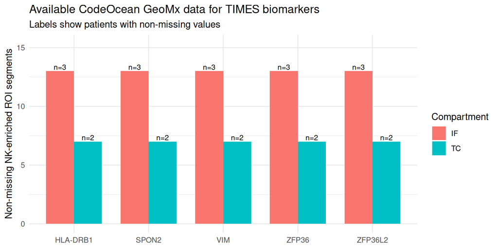

```r
ggplot2::ggplot(
  coverage_by_gene_compartment,
  ggplot2::aes(
    x = forcats::fct_reorder(.data$gene, .data$n_segments),
    y = .data$n_segments,
    fill = .data$compartment
  )
) +
  ggplot2::geom_col(position = "dodge", width = 0.75) +
  ggplot2::geom_text(
    ggplot2::aes(label = paste0("n=", .data$n_patients)),
    position = ggplot2::position_dodge(width = 0.75),
    vjust = -0.25,
    size = 3
  ) +
  ggplot2::coord_cartesian(ylim = c(0, max(coverage_by_gene_compartment$n_segments) * 1.18)) +
  ggplot2::labs(
    x = NULL,
    y = "Non-missing NK-enriched ROI segments",
    fill = "Compartment",
    title = "Available CodeOcean GeoMx data for TIMES biomarkers",
    subtitle = "Labels show patients with non-missing values"
  )
```

# Paper ground truth and proxy hypothesis

The paper gives a **recurrence/spatial** ground truth, not a healthy-liver-versus-HCC ground truth. TIMES uses spatial expression patterns in HCC IF/TC to predict recurrence, and spatial integration is central to the published score. Extended Data Fig. 1 shows greater NK enrichment at IF in non-REC HCC, while Extended Data Fig. 5 links SPON2+ NK cells to activation, IFN-gamma/perforin and migration-related programs.

For the five TIMES genes, the exact author CodeOcean differential-expression object supports the following **paper-ground-truth recurrence direction**: `non-REC > REC` in both IF and TC for all five biomarkers. This is the only direction assigned a paper-ground-truth match. The posteriorHCA proxy adds a new hypothesis: **non-REC is closer to healthy liver NK than REC**. That proxy hypothesis is evaluated against recurrence labels but is not claimed as paper ground truth. The SPON2 evidence provides mechanistic context, but it does not specify a SPON2 direction relative to healthy liver NK.

```r
paper_de_path <- file.path(
  params$case_dir,
  "codeocean",
  "data",
  "Input_1_Spatial_transcriptomics_analysis",
  "transcriptome_differential_analysis_input_3.RData"
)

if (!file.exists(paper_de_path)) {
  stop("Missing CodeOcean paper DE input: ", paper_de_path)
}

paper_env <- new.env(parent = emptyenv())
suppressWarnings(load(paper_de_path, envir = paper_env))
paper_niky_de <- get("niky_de", envir = paper_env)

paper_ground_truth <- paper_niky_de |>
  tibble::as_tibble() |>
  dplyr::filter(.data$gene %in% times_biomarkers$gene) |>
  dplyr::transmute(
    gene = .data$gene,
    paper_l2fc_nonrec_vs_rec_if =
      .data$l2fc_1Nonrelp_NKatBorder_agst_0Relp_NKatBorder,
    paper_padj_nonrec_vs_rec_if =
      .data$padj_1Nonrelp_NKatBorder_agst_0Relp_NKatBorder,
    paper_l2fc_nonrec_vs_rec_tc =
      .data$l2fc_1Nonrelp_NKatTumor_agst_0Relp_NKatTumor,
    paper_padj_nonrec_vs_rec_tc =
      .data$padj_1Nonrelp_NKatTumor_agst_0Relp_NKatTumor,
    paper_l2fc_nonrec_vs_rec_all =
      .data$l2fc_1Nonrelp_agst_0Relp,
    paper_padj_nonrec_vs_rec_all =
      .data$padj_1Nonrelp_agst_0Relp
  ) |>
  dplyr::mutate(
    expected_recurrence_direction_if = dplyr::if_else(
      .data$paper_l2fc_nonrec_vs_rec_if > 0,
      "non-REC higher",
      "REC higher"
    ),
    expected_recurrence_direction_tc = dplyr::if_else(
      .data$paper_l2fc_nonrec_vs_rec_tc > 0,
      "non-REC higher",
      "REC higher"
    ),
    expected_vs_healthy_liver = "not_defined_by_paper",
    expected_vs_healthy_liver_note = dplyr::case_when(
      .data$gene == "SPON2" ~
        "SPON2 has mechanistic support for NK activation and migration, but the paper does not define an expected direction versus healthy liver NK.",
      TRUE ~
        "The paper supports recurrence/spatial prediction, not a healthy-liver up/down hypothesis."
    )
  ) |>
  dplyr::left_join(
    times_biomarkers |>
      dplyr::select(gene, .feature),
    by = "gene"
  ) |>
  dplyr::arrange(.data$gene)

readr::write_csv(paper_ground_truth, params$paper_ground_truth_csv)

paper_ground_truth |>
  dplyr::mutate(dplyr::across(dplyr::where(is.numeric), ~round(.x, 4)))
```

| gene | paper_l2fc_nonrec_vs_rec_if | paper_padj_nonrec_vs_rec_if | paper_l2fc_nonrec_vs_rec_tc | paper_padj_nonrec_vs_rec_tc | paper_l2fc_nonrec_vs_rec_all | paper_padj_nonrec_vs_rec_all | expected_recurrence_direction_if | expected_recurrence_direction_tc | expected_vs_healthy_liver | expected_vs_healthy_liver_note | .feature |
| --- | --- | --- | --- | --- | --- | --- | --- | --- | --- | --- | --- |
| HLA-DRB1 | 2.5086 | 0 | 2.4548 | 0 | 2.2816 | 0 | non-REC higher | non-REC higher | not_defined_by_paper | The paper supports recurrence/spatial prediction, not a healthy-liver up/down hypothesis. | ENSG00000196126 |
| SPON2 | 1.6153 | 0 | 4.1904 | 0 | 2.2358 | 0 | non-REC higher | non-REC higher | not_defined_by_paper | SPON2 has mechanistic support for NK activation and migration, but the paper does not define an expected direction versus healthy liver NK. | ENSG00000159674 |
| VIM | 2.9614 | 0 | 3.2576 | 0 | 2.8116 | 0 | non-REC higher | non-REC higher | not_defined_by_paper | The paper supports recurrence/spatial prediction, not a healthy-liver up/down hypothesis. | ENSG00000026025 |
| ZFP36 | 2.0943 | 0 | 2.2027 | 0 | 1.7875 | 0 | non-REC higher | non-REC higher | not_defined_by_paper | The paper supports recurrence/spatial prediction, not a healthy-liver up/down hypothesis. | ENSG00000128016 |
| ZFP36L2 | 2.6389 | 0 | 3.1486 | 0 | 2.5038 | 0 | non-REC higher | non-REC higher | not_defined_by_paper | The paper supports recurrence/spatial prediction, not a healthy-liver up/down hypothesis. | ENSG00000152518 |

# Comprehensive healthy baseline draws

```r
fit_levels <- function(fit, var) {
  d <- fit$data
  if (is.null(d) || !var %in% names(d)) {
    return(character(0))
  }
  v <- d[[var]]
  lv <- if (is.factor(v)) levels(v) else sort(unique(as.character(v)))
  lv[!is.na(lv) & nzchar(lv)]
}

newdata_comprehensive_baseline <- function() {
  tibble::tibble(
    age_decade = NA_character_,
    sex = NA_character_,
    ethnicity_groups = NA_character_,
    assay_groups_altered = NA_character_,
    disease_groups_altered = "Normal",
    tissue_groups = params$baseline_tissue_group,
    offset = 0
  )
}

build_comprehensive_grid <- function(
    fit,
    newdata = newdata_comprehensive_baseline(),
    marginalize_over = c(
      "sex", "age_decade", "ethnicity_groups", "assay_groups_altered"
    ),
    new_level_cols = "dataset_id_altered",
    new_level_tag = "__comprehensive_healthy_baseline__"
) {
  newdata <- tibble::as_tibble(newdata)
  fit_vars <- colnames(fit$data)

  levels_list <- lapply(intersect(marginalize_over, fit_vars), function(col) {
    fit_levels(fit, col)
  })
  names(levels_list) <- intersect(marginalize_over, fit_vars)
  levels_list <- levels_list[vapply(levels_list, length, integer(1L)) > 0L]

  if (length(levels_list)) {
    grid <- do.call(tidyr::expand_grid, levels_list)
    rest <- newdata[, setdiff(names(newdata), names(levels_list)), drop = FALSE]
    out <- dplyr::bind_cols(rest[rep(1L, nrow(grid)), , drop = FALSE], grid)
  } else {
    out <- newdata
  }

  for (col in new_level_cols) {
    if (col %in% fit_vars) {
      out[[col]] <- new_level_tag
    }
  }

  tibble::as_tibble(out)
}

read_fit_for_feature <- function(feature_id) {
  target_name <- model_meta |>
    dplyr::filter(.data$.feature == feature_id) |>
    dplyr::slice(1) |>
    dplyr::pull(.data$name)

  if (!length(target_name)) {
    stop("No target found for feature ", feature_id)
  }

  chunk <- targets::tar_read_raw(
    target_name[[1]],
    store = file.path(model_path, "_targets")
  )

  chunk$brms_fit[[1]]
}

posterior_linpred_args <- function(fit, nd_grid) {
  args <- list(
    object = fit,
    newdata = nd_grid,
    transform = FALSE,
    re_formula = NULL,
    allow_new_levels = TRUE,
    sample_new_levels = "gaussian"
  )

  n_draws <- params$n_posterior_draws
  if (!is.null(n_draws) && !is.na(n_draws) && is.finite(n_draws) && n_draws > 0) {
    n_available <- tryCatch(
      posterior::ndraws(posterior::as_draws_df(fit)),
      error = function(e) NA_integer_
    )
    if (!is.na(n_available)) {
      n_draws <- min(as.integer(n_draws), n_available)
    }
    args$ndraws <- as.integer(n_draws)
  }

  args
}

compute_one_baseline <- function(gene, feature_id) {
  fit <- read_fit_for_feature(feature_id)
  nd_grid <- build_comprehensive_grid(fit)

  log_mu_mat <- do.call(
    brms::posterior_linpred,
    posterior_linpred_args(fit, nd_grid)
  )

  grand_mean_draws <- rowMeans(log_mu_mat)

  tibble::tibble(
    gene = gene,
    .feature = feature_id,
    draw = seq_along(grand_mean_draws),
    baseline_log_mu = as.numeric(grand_mean_draws),
    n_grid_rows = nrow(nd_grid)
  )
}
```

```r
baseline_features <- biomarker_model_status |>
  dplyr::filter(.data$in_v1_nk_store) |>
  dplyr::select(gene, .feature)

if (file.exists(params$baseline_draws_rds) && !isTRUE(params$refresh_baseline)) {
  baseline_draws <- readRDS(params$baseline_draws_rds)
} else {
  baseline_draws <- purrr::map2_dfr(
    baseline_features$gene,
    baseline_features$.feature,
    compute_one_baseline
  )
  saveRDS(baseline_draws, params$baseline_draws_rds, compress = "xz")
}

baseline_summary <- baseline_draws |>
  dplyr::group_by(.data$gene, .data$.feature) |>
  dplyr::summarise(
    n_draws = dplyr::n(),
    n_grid_rows = dplyr::first(.data$n_grid_rows),
    baseline_mean_log_mu = mean(.data$baseline_log_mu),
    baseline_sd_log_mu = stats::sd(.data$baseline_log_mu),
    baseline_q025 = stats::quantile(.data$baseline_log_mu, 0.025),
    baseline_q500 = stats::quantile(.data$baseline_log_mu, 0.5),
    baseline_q975 = stats::quantile(.data$baseline_log_mu, 0.975),
    baseline_median_mu = stats::median(exp(.data$baseline_log_mu)),
    .groups = "drop"
  )

baseline_summary
```

| gene | .feature | n_draws | n_grid_rows | baseline_mean_log_mu | baseline_sd_log_mu | baseline_q025 | baseline_q500 | baseline_q975 | baseline_median_mu |
| --- | --- | --- | --- | --- | --- | --- | --- | --- | --- |
| SPON2 | ENSG00000159674 | 400 | 840 | 7.171185 | 1.003588 | 5.072416 | 7.158793 | 9.208721 | 1285.3587 |
| VIM | ENSG00000026025 | 400 | 840 | 6.431781 | 1.475106 | 3.964878 | 6.273413 | 9.654900 | 530.2843 |
| ZFP36 | ENSG00000128016 | 400 | 840 | 6.806596 | 1.490998 | 4.011699 | 6.839847 | 9.657474 | 934.3466 |
| ZFP36L2 | ENSG00000152518 | 400 | 840 | 7.037935 | 1.224366 | 4.721699 | 7.036394 | 9.393483 | 1137.3075 |

# Patient pseudobulk and SAVI-aligned offsets

The public capsule provides one processed expression column per GeoMx ROI. As in the authors’ DESeq2 script, values are rounded before count modelling. To retain patients as the independent units, NK-enriched ROI columns are summed within each patient x compartment. The resulting five samples form four cohorts: **IF-REC**, **IF-non-REC**, **TC-REC** and **TC-non-REC**.

For exact SAVI-style scaling, the patient pseudobulks are merged with the single `V1_nk` training reference sample whose stored offset is zero. We then call `tidybulk::scale_abundance(method = "TMMwsp", reference_sample = "reference")` and define `offset = log(1 / multiplier)`, exactly as in the SAVI report.

```r
expression_path <- file.path(
  processed_dir,
  "codeocean_GeoMx_all_gene_expression_matrix.csv"
)
roi_metadata_path <- file.path(
  processed_dir,
  "codeocean_GeoMx_all_roi_metadata.csv"
)

geomx_expression_df <- utils::read.csv(
  expression_path,
  check.names = FALSE,
  stringsAsFactors = FALSE
)
geomx_roi_meta <- readr::read_csv(
  roi_metadata_path,
  show_col_types = FALSE
) |>
  dplyr::filter(
    .data$included_in_author_nk_analysis,
    .data$compartment %in% target_compartments
  ) |>
  dplyr::mutate(
    sample_id = paste(.data$patient_id, .data$compartment, sep = "_"),
    cohort = paste(
      .data$compartment,
      dplyr::if_else(.data$recurrence == "REC", "REC", "non_REC"),
      sep = "_"
    )
  )

geomx_expression <- as.matrix(geomx_expression_df[, -1, drop = FALSE])
mode(geomx_expression) <- "numeric"
rownames(geomx_expression) <- geomx_expression_df$gene

patient_pseudobulk_meta <- geomx_roi_meta |>
  dplyr::distinct(
    .data$sample_id, .data$patient_id, .data$compartment,
    .data$recurrence, .data$cohort, .data$age, .data$gender
  ) |>
  dplyr::arrange(.data$compartment, .data$recurrence, .data$patient_id) |>
  dplyr::mutate(
    n_rois = purrr::map_int(.data$sample_id, function(id) {
      sum(geomx_roi_meta$sample_id == id)
    })
  )

roi_columns_by_sample <- split(
  geomx_roi_meta$author_column,
  geomx_roi_meta$sample_id
)

patient_counts_symbol <- do.call(
  cbind,
  purrr::map(
    patient_pseudobulk_meta$sample_id,
    function(id) {
      values <- round(
        geomx_expression[, roi_columns_by_sample[[id]], drop = FALSE]
      )
      n_non_missing <- rowSums(!is.na(values))
      counts <- rowSums(values, na.rm = TRUE)
      counts[n_non_missing == 0L] <- NA_real_
      counts
    }
  )
)

colnames(patient_counts_symbol) <- patient_pseudobulk_meta$sample_id
rownames(patient_counts_symbol) <- rownames(geomx_expression)

times_panel_samples <- colnames(patient_counts_symbol)[
  colSums(
    !is.na(patient_counts_symbol[times_biomarkers$gene, , drop = FALSE])
  ) == nrow(times_biomarkers)
]
patient_counts_symbol <- patient_counts_symbol[
  , times_panel_samples, drop = FALSE
]
patient_pseudobulk_meta <- patient_pseudobulk_meta |>
  dplyr::filter(.data$sample_id %in% times_panel_samples) |>
  dplyr::arrange(match(.data$sample_id, times_panel_samples))

symbol_to_ensembl <- AnnotationDbi::mapIds(
  org.Hs.eg.db::org.Hs.eg.db,
  keys = rownames(patient_counts_symbol),
  column = "ENSEMBL",
  keytype = "SYMBOL",
  multiVals = "first"
)
keep_mapping <- !is.na(symbol_to_ensembl) & !duplicated(symbol_to_ensembl)
patient_counts <- patient_counts_symbol[keep_mapping, , drop = FALSE]
rownames(patient_counts) <- unname(symbol_to_ensembl[keep_mapping])

readr::write_csv(
  patient_pseudobulk_meta,
  params$patient_pseudobulk_csv
)

patient_pseudobulk_meta
```

| sample_id | patient_id | compartment | recurrence | cohort | age | gender | n_rois |
| --- | --- | --- | --- | --- | --- | --- | --- |
| A29_IF | A29 | IF | REC | IF_REC | 57 | Male | 4 |
| A24_IF | A24 | IF | non-REC | IF_non_REC | 41 | Female | 2 |
| A6_IF | A6 | IF | non-REC | IF_non_REC | 57 | Male | 7 |
| A29_TC | A29 | TC | REC | TC_REC | 57 | Male | 4 |
| A24_TC | A24 | TC | non-REC | TC_non_REC | 41 | Female | 3 |

```r
pseudobulk_sample <- targets::tar_read(
  pseudobulk_sample,
  store = file.path(model_path, "_targets")
)

if (!file.exists(params$pseudobulk_h5ad)) {
  stop("Missing local pseudobulk H5AD: ", params$pseudobulk_h5ad)
}

pseudobulk_sample@assays@data@listData[["counts"]]@seed@seed@seed@filepath <-
  params$pseudobulk_h5ad

reference_idx <- which(
  as.data.frame(SummarizedExperiment::colData(pseudobulk_sample))$offset == 0
)
if (length(reference_idx) != 1L) {
  stop("Expected exactly one V1_nk training sample with offset == 0.")
}

common_features <- intersect(rownames(patient_counts), rownames(pseudobulk_sample))
reference_counts <- as.numeric(
  SummarizedExperiment::assay(pseudobulk_sample, "counts")[
    common_features, reference_idx
  ]
)

counts_mu <- cbind(
  patient_counts[common_features, , drop = FALSE],
  reference = reference_counts
)
complete_features <- rowSums(is.na(counts_mu)) == 0L &
  rowSums(counts_mu, na.rm = TRUE) >= 5
counts_mu <- counts_mu[complete_features, , drop = FALSE]

cohort_levels <- c("IF_REC", "IF_non_REC", "TC_REC", "TC_non_REC")
meta_mu <- dplyr::bind_rows(
  patient_pseudobulk_meta |>
    dplyr::transmute(
      sample_id, patient_id, compartment, recurrence, cohort,
      sample_role = "hcc_patient_pseudobulk"
    ),
  tibble::tibble(
    sample_id = "reference",
    patient_id = NA_character_,
    compartment = NA_character_,
    recurrence = NA_character_,
    cohort = "reference",
    sample_role = "atlas_training_reference"
  )
) |>
  dplyr::mutate(
    group = factor(.data$cohort, levels = c("reference", cohort_levels))
  )

stopifnot(identical(colnames(counts_mu), meta_mu$sample_id))

se_mu <- SummarizedExperiment::SummarizedExperiment(
  assays = list(counts = counts_mu),
  colData = S4Vectors::DataFrame(
    as.data.frame(meta_mu),
    row.names = meta_mu$sample_id
  ),
  rowData = S4Vectors::DataFrame(
    .feature = rownames(counts_mu),
    row.names = rownames(counts_mu)
  )
)

reference_row_data <- as.data.frame(
  SummarizedExperiment::rowData(pseudobulk_sample)
)
abundant_cols <- grep(
  "^\\.abundant",
  names(reference_row_data),
  value = TRUE
)
if (length(abundant_cols) >= 1L) {
  SummarizedExperiment::rowData(se_mu)$.abundant <-
    reference_row_data[
      rownames(se_mu),
      abundant_cols[[1]],
      drop = TRUE
    ]
}

reference_sample_name <- meta_mu$sample_id[
  meta_mu$sample_role == "atlas_training_reference"
]
if (length(reference_sample_name) != 1L) {
  stop("Expected exactly one atlas training reference sample.")
}

se_mu <- se_mu |>
  tidybulk::scale_abundance(
    method = "TMMwsp",
    reference_sample = reference_sample_name
  )
SummarizedExperiment::colData(se_mu)$offset <- log(
  1 / SummarizedExperiment::colData(se_mu)$multiplier
)

counts_mu <- SummarizedExperiment::assay(se_mu, "counts")
meta_mu <- SummarizedExperiment::colData(se_mu) |>
  as.data.frame()
offset_vec_mu <- meta_mu$offset

dge_mu <- edgeR::DGEList(
  counts = counts_mu,
  samples = meta_mu,
  genes = data.frame(.feature = rownames(counts_mu))
)
reference_column <- which(meta_mu$sample_role == "atlas_training_reference")
dge_mu$offset <- matrix(
  offset_vec_mu,
  nrow = nrow(dge_mu),
  ncol = ncol(dge_mu),
  byrow = TRUE
)

normalization_audit <- meta_mu |>
  dplyr::mutate(
    library_size = colSums(counts_mu),
    offset = offset_vec_mu,
    reference_sample = .data$sample_id == reference_sample_name
  )

readr::write_csv(normalization_audit, params$normalization_csv)

normalization_audit |>
  dplyr::select(
    sample_id, patient_id, cohort, sample_role,
    library_size, multiplier, offset, reference_sample
  ) |>
  dplyr::mutate(dplyr::across(dplyr::where(is.numeric), ~round(.x, 4)))
```

|  | sample_id | patient_id | cohort | sample_role | library_size | multiplier | offset | reference_sample |
| --- | --- | --- | --- | --- | --- | --- | --- | --- |
| A29_IF | A29_IF | A29 | IF_REC | hcc_patient_pseudobulk | 785997 | 1.7643 | -0.5678 | FALSE |
| A24_IF | A24_IF | A24 | IF_non_REC | hcc_patient_pseudobulk | 618883 | 2.7611 | -1.0156 | FALSE |
| A6_IF | A6_IF | A6 | IF_non_REC | hcc_patient_pseudobulk | 2419758 | 0.8402 | 0.1741 | FALSE |
| A29_TC | A29_TC | A29 | TC_REC | hcc_patient_pseudobulk | 816154 | 1.6709 | -0.5134 | FALSE |
| A24_TC | A24_TC | A24 | TC_non_REC | hcc_patient_pseudobulk | 1104464 | 1.8963 | -0.6399 | FALSE |
| reference | reference | NA | reference | atlas_training_reference | 2427070 | 1.0000 | 0.0000 | TRUE |

# Healthy-reference cohort estimates

These estimates provide the inputs to the posteriorHCA recurrence proxy. The SAVI-style group-means design is `~ 0 + group`. For each gene x cohort:

- cohort `log(mu)` at offset zero is the edgeR NB MLE from `mglmOneGroup`;
- cohort uncertainty is the QL Wald SE from `glmQLFit`;
- the healthy comparator is the posterior of the comprehensive liver NK grand mean, not the full heterogeneous predictive distribution;
- Welch is the parametric test and posterior rank is the non-parametric check.

```r
design_mu <- stats::model.matrix(~ 0 + group, data = dge_mu$samples)
colnames(design_mu) <- sub("^group", "", colnames(design_mu))

dge_mu <- edgeR::estimateDisp(dge_mu, design_mu)
fit_mu <- edgeR::glmQLFit(dge_mu, design_mu)

nb_dispersion_mu <- if (!is.null(dge_mu$trended.dispersion)) {
  dge_mu$trended.dispersion
} else if (!is.null(dge_mu$tagwise.dispersion)) {
  dge_mu$tagwise.dispersion
} else {
  rep_len(dge_mu$common.dispersion, nrow(dge_mu))
}

tibble::tibble(
  n_features_fit = nrow(dge_mu),
  n_patient_pseudobulks = sum(meta_mu$sample_role == "hcc_patient_pseudobulk"),
  design_groups = paste(colnames(design_mu), collapse = ", "),
  residual_df = paste(unique(fit_mu$df.residual), collapse = ", "),
  reference_offset = offset_vec_mu[reference_column]
)
```

| n_features_fit | n_patient_pseudobulks | design_groups | residual_df | reference_offset |
| --- | --- | --- | --- | --- |
| 7523 | 5 | reference, IF_REC, IF_non_REC, TC_REC, TC_non_REC | 1 | 0 |

```r
welch_t_from_mean_se <- function(mean1, se1, n1, mean2, se2, n2) {
  sd1 <- se1 * sqrt(n1)
  sd2 <- se2 * sqrt(n2)
  se_diff <- sqrt(se1^2 + se2^2)
  t_stat <- (mean1 - mean2) / se_diff
  df <- (sd1^2 / n1 + sd2^2 / n2)^2 /
    ((sd1^2 / n1)^2 / (n1 - 1) + (sd2^2 / n2)^2 / (n2 - 1))
  p_value <- 2 * stats::pt(abs(t_stat), df = df, lower.tail = FALSE)
  list(
    mean_diff = mean1 - mean2,
    se_diff = se_diff,
    t = t_stat,
    df = df,
    p_value = p_value
  )
}

edger_log_mu_cohort <- function(feature_id, cohort) {
  gi <- match(feature_id, rownames(fit_mu))
  if (is.na(gi) || !cohort %in% colnames(fit_mu$coefficients)) {
    return(NULL)
  }

  j <- which(fit_mu$samples$group == cohort)
  if (!length(j)) {
    return(NULL)
  }

  dispersion <- nb_dispersion_mu[gi]
  log_mu <- edgeR::mglmOneGroup(
    matrix(counts_mu[gi, j], nrow = 1),
    dispersion = dispersion,
    offset = offset_vec_mu[j]
  )

  mu_all <- fit_mu$fitted.values[gi, ]
  weights <- mu_all / (1 + dispersion * mu_all)
  cohort_weight <- sum(weights[j])
  se <- if (is.finite(cohort_weight) && cohort_weight > 0) {
    sqrt(fit_mu$s2.post[gi] / cohort_weight)
  } else {
    Inf
  }

  list(
    log_mu = unname(log_mu),
    mu = unname(exp(log_mu)),
    se = unname(se),
    df = unname(fit_mu$df.residual.adj[gi]),
    n = length(j),
    patient_ids = paste(
      sort(stats::na.omit(fit_mu$samples$patient_id[j])),
      collapse = ", "
    )
  )
}

test_cohort_against_baseline <- function(gene, feature_id, cohort) {
  cm <- edger_log_mu_cohort(feature_id, cohort)
  if (is.null(cm)) {
    return(NULL)
  }

  baseline <- baseline_summary |>
    dplyr::filter(.data$gene == gene, .data$.feature == feature_id)
  draws <- baseline_draws |>
    dplyr::filter(.data$gene == gene, .data$.feature == feature_id) |>
    dplyr::pull(.data$baseline_log_mu)

  welch <- welch_t_from_mean_se(
    mean1 = baseline$baseline_mean_log_mu,
    se1 = baseline$baseline_sd_log_mu,
    n1 = baseline$n_draws,
    mean2 = cm$log_mu,
    se2 = cm$se,
    n2 = cm$df + 1
  )
  rank_p_upper <- mean(draws >= cm$log_mu)
  rank_p_lower <- mean(draws <= cm$log_mu)

  tibble::tibble(
    gene = gene,
    .feature = feature_id,
    cohort = cohort,
    compartment = sub("_.*$", "", cohort),
    recurrence = dplyr::if_else(
      grepl("non_REC$", cohort), "non-REC", "REC"
    ),
    patient_ids = cm$patient_ids,
    cohort_n = cm$n,
    cohort_log_mu = cm$log_mu,
    cohort_mu = cm$mu,
    cohort_se = cm$se,
    baseline_mean_log_mu = baseline$baseline_mean_log_mu,
    baseline_sd_grand_mean = baseline$baseline_sd_log_mu,
    delta_log_mu_vs_baseline =
      cm$log_mu - baseline$baseline_mean_log_mu,
    welch_t = welch$t,
    welch_df = welch$df,
    welch_p = welch$p_value,
    rank_p_upper = rank_p_upper,
    rank_p_lower = rank_p_lower,
    rank_p_two = min(1, 2 * min(rank_p_upper, rank_p_lower)),
    direction_vs_baseline = dplyr::case_when(
      cm$log_mu > baseline$baseline_mean_log_mu ~ "above_baseline",
      cm$log_mu < baseline$baseline_mean_log_mu ~ "below_baseline",
      TRUE ~ "at_baseline"
    ),
    significant_welch_05 = welch$p_value < 0.05
  )
}
```

```r
baseline_features <- biomarker_model_status |>
  dplyr::filter(
    .data$in_v1_nk_store,
    .data$.feature %in% rownames(fit_mu)
  ) |>
  dplyr::select(gene, .feature)

cohort_tests <- tidyr::crossing(
  baseline_features,
  cohort = cohort_levels
) |>
  purrr::pmap_dfr(function(gene, .feature, cohort) {
    test_cohort_against_baseline(gene, .feature, cohort)
  }) |>
  dplyr::mutate(
    cohort = factor(.data$cohort, levels = cohort_levels)
  ) |>
  dplyr::arrange(.data$gene, .data$cohort)

readr::write_csv(cohort_tests, params$cohort_results_csv)

cohort_tests |>
  dplyr::select(
    gene, cohort, patient_ids, cohort_n, cohort_log_mu, cohort_se,
    baseline_mean_log_mu, delta_log_mu_vs_baseline,
    welch_p, rank_p_two, direction_vs_baseline
  ) |>
  dplyr::mutate(dplyr::across(dplyr::where(is.numeric), ~round(.x, 4)))
```

| gene | cohort | patient_ids | cohort_n | cohort_log_mu | cohort_se | baseline_mean_log_mu | delta_log_mu_vs_baseline | welch_p | rank_p_two | direction_vs_baseline |
| --- | --- | --- | --- | --- | --- | --- | --- | --- | --- | --- |
| SPON2 | IF_REC | A29 | 1 | 5.1111 | 0.2110 | 7.1712 | -2.0601 | 0.0457 | 0.055 | below_baseline |
| SPON2 | IF_non_REC | A24, A6 | 2 | 6.1686 | 0.1424 | 7.1712 | -1.0025 | 0.3233 | 0.260 | below_baseline |
| SPON2 | TC_REC | A29 | 1 | 4.7900 | 0.2154 | 7.1712 | -2.3812 | 0.0212 | 0.045 | below_baseline |
| SPON2 | TC_non_REC | A24 | 1 | 7.1679 | 0.1982 | 7.1712 | -0.0033 | 0.9974 | 0.985 | below_baseline |
| VIM | IF_REC | A29 | 1 | 4.5381 | 0.1933 | 6.4318 | -1.8937 | 0.2039 | 0.145 | below_baseline |
| VIM | IF_non_REC | A24, A6 | 2 | 7.3316 | 0.1211 | 6.4318 | 0.8998 | 0.5436 | 0.475 | above_baseline |
| VIM | TC_REC | A29 | 1 | 4.3846 | 0.1956 | 6.4318 | -2.0472 | 0.1697 | 0.130 | below_baseline |
| VIM | TC_non_REC | A24 | 1 | 6.1371 | 0.1751 | 6.4318 | -0.2947 | 0.8428 | 0.895 | below_baseline |
| ZFP36 | IF_REC | A29 | 1 | 4.9622 | 0.2377 | 6.8066 | -1.8444 | 0.2227 | 0.230 | below_baseline |
| ZFP36 | IF_non_REC | A24, A6 | 2 | 7.3088 | 0.1555 | 6.8066 | 0.5022 | 0.7378 | 0.760 | above_baseline |

[output cut: 6 more lines]

```r
cohort_test_summary <- cohort_tests |>
  dplyr::group_by(.data$cohort) |>
  dplyr::summarise(
    n_genes_tested = dplyr::n_distinct(.data$gene),
    n_above_baseline = sum(.data$direction_vs_baseline == "above_baseline"),
    n_below_baseline = sum(.data$direction_vs_baseline == "below_baseline"),
    n_welch_p_lt_05 = sum(.data$welch_p < 0.05),
    median_delta_log_mu = stats::median(
      .data$delta_log_mu_vs_baseline, na.rm = TRUE
    ),
    .groups = "drop"
  )

cohort_test_summary
```

| cohort | n_genes_tested | n_above_baseline | n_below_baseline | n_welch_p_lt_05 | median_delta_log_mu |
| --- | --- | --- | --- | --- | --- |
| IF_REC | 4 | 0 | 4 | 1 | -1.9769289 |
| IF_non_REC | 4 | 3 | 1 | 0 | 0.2991792 |
| TC_REC | 4 | 0 | 4 | 1 | -2.1616559 |
| TC_non_REC | 4 | 0 | 4 | 0 | -0.4115241 |

# Positive control: non-REC greater than REC within IF and TC

Recurrence is tested with edgeR quasi-likelihood contrasts from the same patient-level counts and offsets. A separate HCC-only fit retains `HLA-DRB1`, which has no matching atlas feature/model for the healthy-baseline comparison. The contrast is `non_REC - REC` within each compartment. `p_nonrec_greater` is the pre-specified one-sided p-value; positive log2 fold change supports the paper direction. This positive control is compared directly with paper ground truth. These tests are necessarily low-powered: the public NK-enriched subset contains two non-REC and one REC patient in IF, and one patient in each recurrence arm in TC.

```r
recurrence_complete_features <- rowSums(is.na(patient_counts)) == 0L &
  rowSums(patient_counts, na.rm = TRUE) >= 5
counts_recurrence <- patient_counts[
  recurrence_complete_features, , drop = FALSE
]

meta_recurrence <- patient_pseudobulk_meta |>
  dplyr::mutate(
    group = factor(.data$cohort, levels = cohort_levels)
  )
stopifnot(identical(colnames(counts_recurrence), meta_recurrence$sample_id))

dge_recurrence <- edgeR::DGEList(
  counts = counts_recurrence,
  samples = as.data.frame(meta_recurrence),
  genes = data.frame(.feature = rownames(counts_recurrence))
)
offset_vec_recurrence <- offset_vec_mu[
  match(meta_recurrence$sample_id, meta_mu$sample_id)
]
dge_recurrence$offset <- matrix(
  offset_vec_recurrence,
  nrow = nrow(dge_recurrence),
  ncol = ncol(dge_recurrence),
  byrow = TRUE
)

design_recurrence <- stats::model.matrix(
  ~ 0 + group,
  data = dge_recurrence$samples
)
colnames(design_recurrence) <- sub(
  "^group", "", colnames(design_recurrence)
)
dge_recurrence <- edgeR::estimateDisp(
  dge_recurrence,
  design_recurrence
)
fit_recurrence <- edgeR::glmQLFit(
  dge_recurrence,
  design_recurrence
)

nb_dispersion_recurrence <- if (
  !is.null(dge_recurrence$trended.dispersion)
) {
  dge_recurrence$trended.dispersion
} else if (!is.null(dge_recurrence$tagwise.dispersion)) {
  dge_recurrence$tagwise.dispersion
} else {
  rep_len(
    dge_recurrence$common.dispersion,
    nrow(dge_recurrence)
  )
}

tibble::tibble(
  n_features_fit = nrow(fit_recurrence),
  n_patient_pseudobulks = nrow(fit_recurrence$samples),
  design_groups = paste(colnames(design_recurrence), collapse = ", "),
  residual_df = paste(unique(fit_recurrence$df.residual), collapse = ", "),
  times_genes_available = paste(
    times_biomarkers$gene[
      times_biomarkers$.feature %in% rownames(fit_recurrence)
    ],
    collapse = ", "
  )
)
```

| n_features_fit | n_patient_pseudobulks | design_groups | residual_df | times_genes_available |
| --- | --- | --- | --- | --- |
| 18080 | 5 | IF_REC, IF_non_REC, TC_REC, TC_non_REC | 1 | SPON2, ZFP36L2, ZFP36, VIM, HLA-DRB1 |

```r
edger_log_mu_recurrence <- function(feature_id, cohort) {
  gi <- match(feature_id, rownames(fit_recurrence))
  if (is.na(gi)) {
    return(NULL)
  }
  j <- which(fit_recurrence$samples$group == cohort)
  if (!length(j)) {
    return(NULL)
  }

  log_mu <- edgeR::mglmOneGroup(
    matrix(counts_recurrence[gi, j], nrow = 1),
    dispersion = nb_dispersion_recurrence[gi],
    offset = offset_vec_recurrence[j]
  )

  list(
    log_mu = unname(log_mu),
    mu = unname(exp(log_mu)),
    n = length(j)
  )
}

test_nonrec_greater <- function(gene, feature_id, compartment) {
  gi <- match(feature_id, rownames(fit_recurrence))
  nonrec_group <- paste0(compartment, "_non_REC")
  rec_group <- paste0(compartment, "_REC")
  if (
    is.na(gi) ||
    !all(
      c(nonrec_group, rec_group) %in%
        colnames(fit_recurrence$coefficients)
    )
  ) {
    return(NULL)
  }

  contrast <- stats::setNames(
    rep(0, ncol(fit_recurrence$design)),
    colnames(fit_recurrence$design)
  )
  contrast[nonrec_group] <- 1
  contrast[rec_group] <- -1

  qlf <- edgeR::glmQLFTest(fit_recurrence, contrast = contrast)
  qlf_row <- qlf$table[gi, , drop = FALSE]
  p_two <- qlf_row$PValue
  p_greater <- if (qlf_row$logFC >= 0) p_two / 2 else 1 - p_two / 2

  nonrec_mu <- edger_log_mu_recurrence(feature_id, nonrec_group)
  rec_mu <- edger_log_mu_recurrence(feature_id, rec_group)

  tibble::tibble(
    gene = gene,
    .feature = feature_id,
    compartment = compartment,
    nonrec_group = nonrec_group,
    rec_group = rec_group,
    n_nonrec = nonrec_mu$n,
    n_rec = rec_mu$n,
    nonrec_log_mu = nonrec_mu$log_mu,
    rec_log_mu = rec_mu$log_mu,
    delta_log_mu_nonrec_minus_rec =
      nonrec_mu$log_mu - rec_mu$log_mu,
    qlf_log2fc_nonrec_vs_rec = qlf_row$logFC,
    qlf_F = qlf_row$F,
    qlf_p_two_sided = p_two,
    p_nonrec_greater = p_greater,
    observed_recurrence_direction = dplyr::case_when(
      qlf_row$logFC > 0 ~ "non-REC higher",
      qlf_row$logFC < 0 ~ "REC higher",
      TRUE ~ "tie"
    ),
    significant_nonrec_greater_05 =
      qlf_row$logFC > 0 & p_greater < 0.05
  )
}
```

```r
recurrence_features <- times_biomarkers |>
  dplyr::filter(.data$.feature %in% rownames(fit_recurrence)) |>
  dplyr::select(gene, .feature)

recurrence_tests <- tidyr::crossing(
  recurrence_features,
  compartment = target_compartments
) |>
  purrr::pmap_dfr(function(gene, .feature, compartment) {
    test_nonrec_greater(gene, .feature, compartment)
  }) |>
  dplyr::left_join(
    paper_ground_truth |>
      dplyr::select(
        gene,
        expected_recurrence_direction_if,
        expected_recurrence_direction_tc,
        paper_l2fc_nonrec_vs_rec_if,
        paper_l2fc_nonrec_vs_rec_tc,
        paper_padj_nonrec_vs_rec_if,
        paper_padj_nonrec_vs_rec_tc
      ),
    by = "gene"
  ) |>
  dplyr::mutate(
    expected_recurrence_direction = dplyr::if_else(
      .data$compartment == "IF",
      .data$expected_recurrence_direction_if,
      .data$expected_recurrence_direction_tc
    ),
    paper_l2fc_nonrec_vs_rec = dplyr::if_else(
      .data$compartment == "IF",
      .data$paper_l2fc_nonrec_vs_rec_if,
      .data$paper_l2fc_nonrec_vs_rec_tc
    ),
    paper_padj_nonrec_vs_rec = dplyr::if_else(
      .data$compartment == "IF",
      .data$paper_padj_nonrec_vs_rec_if,
      .data$paper_padj_nonrec_vs_rec_tc
    ),
    recurrence_matches_paper =
      .data$observed_recurrence_direction ==
      .data$expected_recurrence_direction
  ) |>
  dplyr::arrange(.data$gene, .data$compartment)

readr::write_csv(recurrence_tests, params$recurrence_results_csv)

recurrence_tests |>
  dplyr::select(
    gene, compartment, n_nonrec, n_rec,
    qlf_log2fc_nonrec_vs_rec, p_nonrec_greater,
    observed_recurrence_direction, expected_recurrence_direction,
    recurrence_matches_paper
  ) |>
  dplyr::mutate(dplyr::across(dplyr::where(is.numeric), ~round(.x, 4)))
```

| gene | compartment | n_nonrec | n_rec | qlf_log2fc_nonrec_vs_rec | p_nonrec_greater | observed_recurrence_direction | expected_recurrence_direction | recurrence_matches_paper |
| --- | --- | --- | --- | --- | --- | --- | --- | --- |
| HLA-DRB1 | IF | 2 | 1 | 3.7327 | 0.0006 | non-REC higher | non-REC higher | TRUE |
| HLA-DRB1 | TC | 1 | 1 | 1.6950 | 0.0206 | non-REC higher | non-REC higher | TRUE |
| SPON2 | IF | 2 | 1 | 1.5244 | 0.0044 | non-REC higher | non-REC higher | TRUE |
| SPON2 | TC | 1 | 1 | 3.4284 | 0.0001 | non-REC higher | non-REC higher | TRUE |
| VIM | IF | 2 | 1 | 4.0274 | 0.0001 | non-REC higher | non-REC higher | TRUE |
| VIM | TC | 1 | 1 | 2.5255 | 0.0011 | non-REC higher | non-REC higher | TRUE |
| ZFP36 | IF | 2 | 1 | 3.3836 | 0.0003 | non-REC higher | non-REC higher | TRUE |
| ZFP36 | TC | 1 | 1 | 1.4092 | 0.0186 | non-REC higher | non-REC higher | TRUE |
| ZFP36L2 | IF | 2 | 1 | 3.1137 | 0.0005 | non-REC higher | non-REC higher | TRUE |
| ZFP36L2 | TC | 1 | 1 | 2.3823 | 0.0026 | non-REC higher | non-REC higher | TRUE |

# Primary posteriorHCA test: healthy-proximity recurrence proxy

The proxy asks whether recurrence can be recovered using only distance from the healthy atlas. No recurrence labels, paper coefficients or HCC-trained model parameters enter score construction.

We evaluate four properties:

1. **Compatibility split:** REC is more than one healthy SD away while non-REC remains within one healthy SD.
2. **Gene-compartment consistency:** REC distance exceeds non-REC distance for each atlas-covered biomarker in IF and TC.
3. **Posterior evidence:** after propagating healthy posterior and cohort QL uncertainty, the combined REC score remains larger than the non-REC score.
4. **Patient ranking:** the outcome-free score ranks REC above non-REC patients, including leave-one-gene-out sensitivity analyses.

The one-SD threshold is a descriptive compatibility rule, not a significance threshold. Welch and rank p-values remain available in `cohort_tests`.

```r
healthy_proxy_gene_long <- cohort_tests |>
  dplyr::mutate(
    signed_healthy_z =
      .data$delta_log_mu_vs_baseline / .data$baseline_sd_grand_mean,
    healthy_distance = abs(.data$signed_healthy_z),
    within_one_healthy_sd = .data$healthy_distance <= 1,
    recurrence_key = dplyr::if_else(
      .data$recurrence == "REC", "REC", "non_REC"
    )
  )

healthy_proxy_gene <- healthy_proxy_gene_long |>
  dplyr::select(
    gene, .feature, compartment, recurrence_key,
    cohort_log_mu, cohort_se, baseline_mean_log_mu,
    baseline_sd_grand_mean, signed_healthy_z, healthy_distance,
    within_one_healthy_sd
  ) |>
  tidyr::pivot_wider(
    names_from = recurrence_key,
    values_from = c(
      cohort_log_mu, cohort_se, signed_healthy_z,
      healthy_distance, within_one_healthy_sd
    ),
    names_sep = "."
  ) |>
  dplyr::mutate(
    proxy_margin_rec_minus_nonrec =
      .data$healthy_distance.REC - .data$healthy_distance.non_REC,
    rec_farther_from_healthy =
      .data$proxy_margin_rec_minus_nonrec > 0,
    proxy_pattern_matches_hypothesis =
      !.data$within_one_healthy_sd.REC &
      .data$within_one_healthy_sd.non_REC
  ) |>
  dplyr::arrange(.data$gene, .data$compartment)

readr::write_csv(healthy_proxy_gene, params$healthy_proxy_gene_csv)

healthy_proxy_gene |>
  dplyr::select(
    gene, compartment,
    healthy_distance.REC, healthy_distance.non_REC,
    proxy_margin_rec_minus_nonrec,
    rec_farther_from_healthy,
    proxy_pattern_matches_hypothesis
  ) |>
  dplyr::mutate(dplyr::across(dplyr::where(is.numeric), ~round(.x, 3)))
```

| gene | compartment | healthy_distance.REC | healthy_distance.non_REC | proxy_margin_rec_minus_nonrec | rec_farther_from_healthy | proxy_pattern_matches_hypothesis |
| --- | --- | --- | --- | --- | --- | --- |
| SPON2 | IF | 2.053 | 0.999 | 1.054 | TRUE | TRUE |
| SPON2 | TC | 2.373 | 0.003 | 2.369 | TRUE | TRUE |
| VIM | IF | 1.284 | 0.610 | 0.674 | TRUE | TRUE |
| VIM | TC | 1.388 | 0.200 | 1.188 | TRUE | TRUE |
| ZFP36 | IF | 1.237 | 0.337 | 0.900 | TRUE | TRUE |
| ZFP36 | TC | 1.010 | 0.354 | 0.656 | TRUE | TRUE |
| ZFP36L2 | IF | 1.685 | 0.079 | 1.607 | TRUE | TRUE |
| ZFP36L2 | TC | 1.859 | 0.509 | 1.350 | TRUE | TRUE |

```r
n_proxy_draws <- 20000L
set.seed(20250625)

simulate_proxy_gene <- function(gene_name) {
  healthy_draws <- baseline_draws |>
    dplyr::filter(.data$gene == .env$gene_name) |>
    dplyr::pull(.data$baseline_log_mu)
  healthy_sd <- stats::sd(healthy_draws)
  healthy_draw <- sample(
    healthy_draws,
    size = n_proxy_draws,
    replace = TRUE
  )

  purrr::map_dfr(target_compartments, function(compartment_name) {
    rec_row <- cohort_tests |>
      dplyr::filter(
        .data$gene == .env$gene_name,
        .data$compartment == .env$compartment_name,
        .data$recurrence == "REC"
      )
    nonrec_row <- cohort_tests |>
      dplyr::filter(
        .data$gene == .env$gene_name,
        .data$compartment == .env$compartment_name,
        .data$recurrence == "non-REC"
      )
    rec_draw <- stats::rnorm(
      n_proxy_draws,
      mean = rec_row$cohort_log_mu,
      sd = rec_row$cohort_se
    )
    nonrec_draw <- stats::rnorm(
      n_proxy_draws,
      mean = nonrec_row$cohort_log_mu,
      sd = nonrec_row$cohort_se
    )

    tibble::tibble(
      draw = seq_len(n_proxy_draws),
      gene = gene_name,
      compartment = compartment_name,
      rec_score = abs(rec_draw - healthy_draw) / healthy_sd,
      nonrec_score = abs(nonrec_draw - healthy_draw) / healthy_sd,
      margin = rec_score - nonrec_score
    )
  })
}

proxy_draws <- purrr::map_dfr(
  unique(cohort_tests$gene),
  simulate_proxy_gene
)

summarise_proxy_draws <- function(tbl, scope, compartment = NA_character_) {
  tibble::tibble(
    scope = scope,
    compartment = compartment,
    n_genes = dplyr::n_distinct(cohort_tests$gene),
    mean_rec_score = mean(tbl$rec_score),
    mean_nonrec_score = mean(tbl$nonrec_score),
    mean_margin = mean(tbl$margin),
    margin_q025 = stats::quantile(tbl$margin, 0.025),
    margin_q500 = stats::quantile(tbl$margin, 0.5),
    margin_q975 = stats::quantile(tbl$margin, 0.975),
    posterior_prob_rec_farther = mean(tbl$margin > 0),
    posterior_prob_rec_beyond_one_sd = mean(tbl$rec_score > 1),
    posterior_prob_nonrec_within_one_sd = mean(tbl$nonrec_score <= 1),
    posterior_prob_proxy_pattern = mean(
      tbl$rec_score > 1 & tbl$nonrec_score <= 1
    )
  )
}

proxy_gene_posterior_summary <- proxy_draws |>
  dplyr::group_by(.data$gene, .data$compartment) |>
  dplyr::summarise(
    mean_rec_score = mean(.data$rec_score),
    mean_nonrec_score = mean(.data$nonrec_score),
    mean_margin = mean(.data$margin),
    margin_q025 = stats::quantile(.data$margin, 0.025),
    margin_q500 = stats::quantile(.data$margin, 0.5),
    margin_q975 = stats::quantile(.data$margin, 0.975),
    posterior_prob_rec_farther = mean(.data$margin > 0),
    posterior_prob_rec_beyond_one_sd = mean(.data$rec_score > 1),
    posterior_prob_nonrec_within_one_sd = mean(.data$nonrec_score <= 1),
    posterior_prob_proxy_pattern = mean(
      .data$rec_score > 1 & .data$nonrec_score <= 1
    ),
    .groups = "drop"
  ) |>
  dplyr::mutate(scope = "gene_compartment", .before = 1L)

proxy_compartment_draws <- proxy_draws |>
  dplyr::group_by(.data$compartment, .data$draw) |>
  dplyr::summarise(
    rec_score = mean(.data$rec_score),
    nonrec_score = mean(.data$nonrec_score),
    margin = .data$rec_score - .data$nonrec_score,
    .groups = "drop"
  )

proxy_compartment_summary <- proxy_compartment_draws |>
  dplyr::group_by(.data$compartment) |>
  dplyr::summarise(
    scope = "compartment",
    n_genes = dplyr::n_distinct(cohort_tests$gene),
    mean_rec_score = mean(.data$rec_score),
    mean_nonrec_score = mean(.data$nonrec_score),
    mean_margin = mean(.data$margin),
    margin_q025 = stats::quantile(.data$margin, 0.025),
    margin_q500 = stats::quantile(.data$margin, 0.5),
    margin_q975 = stats::quantile(.data$margin, 0.975),
    posterior_prob_rec_farther = mean(.data$margin > 0),
    posterior_prob_rec_beyond_one_sd = mean(.data$rec_score > 1),
    posterior_prob_nonrec_within_one_sd = mean(.data$nonrec_score <= 1),
    posterior_prob_proxy_pattern = mean(
      .data$rec_score > 1 & .data$nonrec_score <= 1
    ),
    .groups = "drop"
  ) |>
  dplyr::relocate(scope)

proxy_combined_draws <- proxy_draws |>
  dplyr::group_by(.data$draw) |>
  dplyr::summarise(
    rec_score = mean(.data$rec_score),
    nonrec_score = mean(.data$nonrec_score),
    margin = .data$rec_score - .data$nonrec_score,
    .groups = "drop"
  )

proxy_combined_summary <- summarise_proxy_draws(
  proxy_combined_draws,
  scope = "combined_IF_TC"
)

healthy_proxy_posterior_summary <- dplyr::bind_rows(
  proxy_gene_posterior_summary,
  proxy_compartment_summary,
  proxy_combined_summary
)

readr::write_csv(
  healthy_proxy_posterior_summary,
  params$healthy_proxy_summary_csv
)

healthy_proxy_posterior_summary |>
  dplyr::filter(.data$scope != "gene_compartment") |>
  dplyr::mutate(dplyr::across(dplyr::where(is.numeric), ~round(.x, 3)))
```

| scope | gene | compartment | mean_rec_score | mean_nonrec_score | mean_margin | margin_q025 | margin_q500 | margin_q975 | posterior_prob_rec_farther | posterior_prob_rec_beyond_one_sd | posterior_prob_nonrec_within_one_sd | posterior_prob_proxy_pattern | n_genes |
| --- | --- | --- | --- | --- | --- | --- | --- | --- | --- | --- | --- | --- | --- |
| compartment | NA | IF | 1.627 | 0.937 | 0.690 | -0.428 | 0.719 | 1.590 | 0.890 | 0.920 | 0.602 | 0.562 | 4 |
| compartment | NA | TC | 1.724 | 0.832 | 0.891 | -0.071 | 0.951 | 1.508 | 0.967 | 0.952 | 0.720 | 0.684 | 4 |
| combined_IF_TC | NA | NA | 1.675 | 0.884 | 0.791 | -0.174 | 0.834 | 1.477 | 0.950 | 0.941 | 0.691 | 0.651 | 4 |

```r
patient_sample_indices <- which(
  meta_mu$sample_role == "hcc_patient_pseudobulk"
)

patient_gene_proxy <- tidyr::crossing(
  sample_index = patient_sample_indices,
  baseline_features
) |>
  purrr::pmap_dfr(function(sample_index, gene, .feature) {
    feature_id <- .feature
    gene_index <- match(feature_id, rownames(fit_mu))
    patient_log_mu <- edgeR::mglmOneGroup(
      matrix(counts_mu[gene_index, sample_index], nrow = 1),
      dispersion = nb_dispersion_mu[gene_index],
      offset = offset_vec_mu[sample_index]
    )
    healthy <- baseline_summary |>
      dplyr::filter(
        .data$gene == .env$gene,
        .data$.feature == .env$feature_id
      )
    signed_healthy_z <- (
      as.numeric(patient_log_mu) - healthy$baseline_mean_log_mu
    ) / healthy$baseline_sd_log_mu

    tibble::tibble(
      sample_id = meta_mu$sample_id[sample_index],
      patient_id = meta_mu$patient_id[sample_index],
      compartment = meta_mu$compartment[sample_index],
      recurrence = meta_mu$recurrence[sample_index],
      gene = gene,
      .feature = feature_id,
      patient_log_mu = as.numeric(patient_log_mu),
      baseline_mean_log_mu = healthy$baseline_mean_log_mu,
      baseline_sd_grand_mean = healthy$baseline_sd_log_mu,
      signed_healthy_z = signed_healthy_z,
      healthy_distance = abs(signed_healthy_z)
    )
  })

patient_compartment_proxy <- patient_gene_proxy |>
  dplyr::group_by(
    .data$sample_id, .data$patient_id,
    .data$compartment, .data$recurrence
  ) |>
  dplyr::summarise(
    n_genes = dplyr::n(),
    healthy_proximity_risk = mean(.data$healthy_distance),
    mean_signed_healthy_z = mean(.data$signed_healthy_z),
    .groups = "drop"
  )

patient_combined_proxy <- patient_compartment_proxy |>
  dplyr::group_by(.data$patient_id, .data$recurrence) |>
  dplyr::summarise(
    n_compartments = dplyr::n(),
    healthy_proximity_risk = mean(.data$healthy_proximity_risk),
    mean_signed_healthy_z = mean(.data$mean_signed_healthy_z),
    .groups = "drop"
  )

patient_proxy_output <- dplyr::bind_rows(
  patient_gene_proxy |>
    dplyr::transmute(
      score_level = "gene_compartment",
      sample_id, patient_id, compartment, recurrence,
      feature = .data$gene,
      healthy_proximity_risk = .data$healthy_distance,
      mean_signed_healthy_z = .data$signed_healthy_z
    ),
  patient_compartment_proxy |>
    dplyr::transmute(
      score_level = "patient_compartment",
      sample_id, patient_id, compartment, recurrence,
      feature = "four_gene_mean",
      healthy_proximity_risk, mean_signed_healthy_z
    ),
  patient_combined_proxy |>
    dplyr::transmute(
      score_level = "patient_combined",
      sample_id = NA_character_,
      patient_id, compartment = "IF_TC_available", recurrence,
      feature = "four_gene_compartment_mean",
      healthy_proximity_risk, mean_signed_healthy_z
    )
)

readr::write_csv(patient_proxy_output, params$healthy_proxy_patient_csv)

patient_compartment_proxy |>
  dplyr::arrange(.data$compartment, .data$healthy_proximity_risk)
```

| sample_id | patient_id | compartment | recurrence | n_genes | healthy_proximity_risk | mean_signed_healthy_z |
| --- | --- | --- | --- | --- | --- | --- |
| A6_IF | A6 | IF | non-REC | 4 | 0.5254036 | -0.1081965 |
| A24_IF | A24 | IF | non-REC | 4 | 0.5431485 | 0.1008803 |
| A29_IF | A29 | IF | REC | 4 | 1.5647240 | -1.5647240 |
| A24_TC | A24 | TC | non-REC | 4 | 0.2666701 | -0.2666701 |
| A29_TC | A29 | TC | REC | 4 | 1.6573469 | -1.6573469 |

```r
rank_auc <- function(recurrence, score) {
  rec <- score[recurrence == "REC"]
  nonrec <- score[recurrence == "non-REC"]
  comparisons <- outer(rec, nonrec, "-")
  mean(comparisons > 0) + 0.5 * mean(comparisons == 0)
}

proxy_performance_one <- function(tbl, method, scope, left_out_gene = NA_character_) {
  rec <- tbl$healthy_proximity_risk[tbl$recurrence == "REC"]
  nonrec <- tbl$healthy_proximity_risk[tbl$recurrence == "non-REC"]
  rank_test <- suppressWarnings(
    stats::wilcox.test(
      rec,
      nonrec,
      alternative = "greater",
      exact = TRUE
    )
  )

  tibble::tibble(
    method = method,
    scope = scope,
    left_out_gene = left_out_gene,
    n_rec = length(rec),
    n_nonrec = length(nonrec),
    auc = rank_auc(tbl$recurrence, tbl$healthy_proximity_risk),
    one_sided_rank_p = rank_test$p.value,
    min_rec_minus_max_nonrec = min(rec) - max(nonrec),
    all_rec_above_nonrec = min(rec) > max(nonrec)
  )
}

proxy_performance <- dplyr::bind_rows(
  purrr::map_dfr(target_compartments, function(compartment) {
    compartment_name <- compartment
    proxy_performance_one(
      patient_compartment_proxy |>
        dplyr::filter(.data$compartment == .env$compartment_name),
      method = "posteriorHCA_healthy_proximity",
      scope = compartment_name
    )
  }),
  proxy_performance_one(
    patient_combined_proxy,
    method = "posteriorHCA_healthy_proximity",
    scope = "combined_available_IF_TC"
  )
)

proxy_leave_one_gene_out <- purrr::map_dfr(
  unique(patient_gene_proxy$gene),
  function(left_out_gene) {
    loo_compartment <- patient_gene_proxy |>
      dplyr::filter(.data$gene != left_out_gene) |>
      dplyr::group_by(
        .data$patient_id, .data$compartment, .data$recurrence
      ) |>
      dplyr::summarise(
        healthy_proximity_risk = mean(.data$healthy_distance),
        .groups = "drop"
      ) |>
      dplyr::group_by(.data$patient_id, .data$recurrence) |>
      dplyr::summarise(
        healthy_proximity_risk = mean(.data$healthy_proximity_risk),
        .groups = "drop"
      )

    proxy_performance_one(
      loo_compartment,
      method = "posteriorHCA_healthy_proximity_LOO_gene",
      scope = "combined_available_IF_TC",
      left_out_gene = left_out_gene
    )
  }
)

healthy_proxy_performance <- dplyr::bind_rows(
  proxy_performance,
  proxy_leave_one_gene_out
)

readr::write_csv(
  healthy_proxy_performance,
  params$healthy_proxy_performance_csv
)

healthy_proxy_performance
```

| method | scope | left_out_gene | n_rec | n_nonrec | auc | one_sided_rank_p | min_rec_minus_max_nonrec | all_rec_above_nonrec |
| --- | --- | --- | --- | --- | --- | --- | --- | --- |
| posteriorHCA_healthy_proximity | IF | NA | 1 | 2 | 1 | 0.3333333 | 1.0215755 | TRUE |
| posteriorHCA_healthy_proximity | TC | NA | 1 | 1 | 1 | 0.5000000 | 1.3906768 | TRUE |
| posteriorHCA_healthy_proximity | combined_available_IF_TC | NA | 1 | 2 | 1 | 0.3333333 | 1.0856319 | TRUE |
| posteriorHCA_healthy_proximity_LOO_gene | combined_available_IF_TC | SPON2 | 1 | 2 | 1 | 0.3333333 | 1.0185737 | TRUE |
| posteriorHCA_healthy_proximity_LOO_gene | combined_available_IF_TC | VIM | 1 | 2 | 1 | 0.3333333 | 1.2189160 | TRUE |
| posteriorHCA_healthy_proximity_LOO_gene | combined_available_IF_TC | ZFP36 | 1 | 2 | 1 | 0.3333333 | 1.1344819 | TRUE |
| posteriorHCA_healthy_proximity_LOO_gene | combined_available_IF_TC | ZFP36L2 | 1 | 2 | 1 | 0.3333333 | 0.9056331 | TRUE |

```r
paper_times_path <- file.path(
  params$case_dir,
  "codeocean",
  "data",
  "Input_2_TIMES_development_from_mIHC",
  "TIMES_distribution_input.RData"
)

paper_times_env <- new.env(parent = emptyenv())
load(paper_times_path, envir = paper_times_env)
paper_rec_scores <- get("liver_r_data_gene_ed", envir = paper_times_env)
paper_nonrec_scores <- get("liver_nr_data_gene_ed", envir = paper_times_env)
paper_rank_test <- stats::wilcox.test(
  paper_rec_scores,
  paper_nonrec_scores,
  alternative = "greater",
  exact = FALSE
)

paper_times_benchmark <- tibble::tibble(
  method = "paper_TIMES_validation_score",
  scope = "mIHC_validation_subset",
  n_rec = length(paper_rec_scores),
  n_nonrec = length(paper_nonrec_scores),
  auc = mean(outer(paper_rec_scores, paper_nonrec_scores, ">")) +
    0.5 * mean(outer(paper_rec_scores, paper_nonrec_scores, "==")),
  one_sided_rank_p = paper_rank_test$p.value,
  comparison_note = paste(
    "Descriptive benchmark from the CodeOcean TIMES distribution input.",
    "Not a formal equivalence test against the GeoMx posteriorHCA proxy."
  )
)

readr::write_csv(paper_times_benchmark, params$paper_benchmark_csv)

dplyr::bind_rows(
  healthy_proxy_performance |>
    dplyr::filter(
      .data$method == "posteriorHCA_healthy_proximity",
      .data$scope == "combined_available_IF_TC"
    ) |>
    dplyr::transmute(
      method, scope, n_rec, n_nonrec, auc, one_sided_rank_p,
      comparison_note =
        "Outcome-free posteriorHCA proxy; only three available patients."
    ),
  paper_times_benchmark
)
```

| method | scope | n_rec | n_nonrec | auc | one_sided_rank_p | comparison_note |
| --- | --- | --- | --- | --- | --- | --- |
| posteriorHCA_healthy_proximity | combined_available_IF_TC | 1 | 2 | 1.00 | 0.3333333 | Outcome-free posteriorHCA proxy; only three available patients. |
| paper_TIMES_validation_score | mIHC_validation_subset | 4 | 7 | 0.75 | 0.1096513 | Descriptive benchmark from the CodeOcean TIMES distribution input. Not a formal equivalence test against the GeoMx posteriorHCA proxy. |

# Visual checks

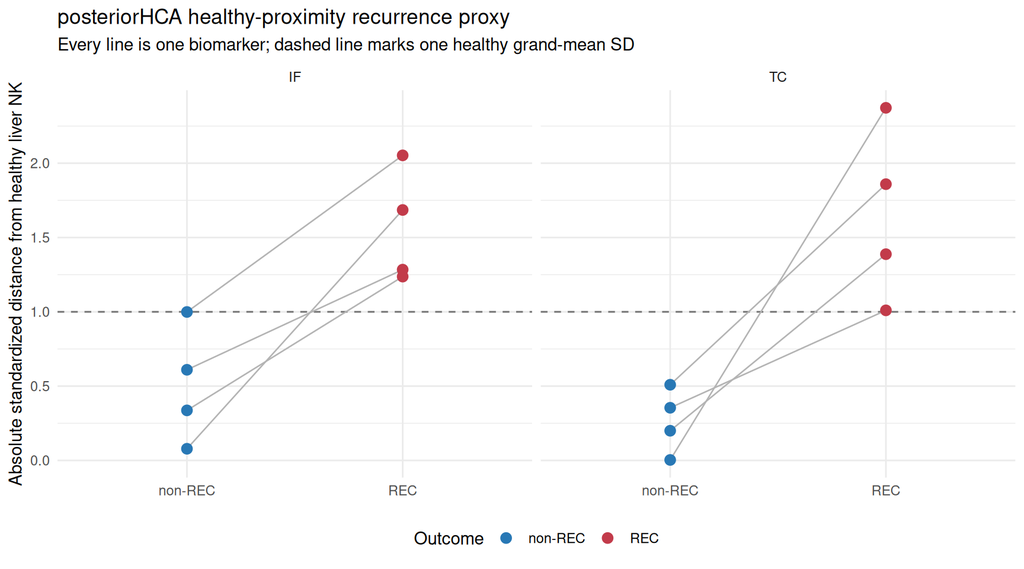

```r
ggplot2::ggplot(
  healthy_proxy_gene_long,
  ggplot2::aes(
    x = .data$recurrence,
    y = .data$healthy_distance,
    colour = .data$recurrence,
    group = interaction(.data$gene, .data$compartment)
  )
) +
  ggplot2::geom_hline(
    yintercept = 1,
    linetype = "dashed",
    colour = "grey45"
  ) +
  ggplot2::geom_line(
    colour = "grey70",
    linewidth = 0.45
  ) +
  ggplot2::geom_point(size = 2.8) +
  ggplot2::facet_wrap(~ compartment) +
  ggplot2::scale_colour_manual(
    values = c(`non-REC` = "#2878B5", REC = "#C23B4A")
  ) +
  ggplot2::labs(
    title = "posteriorHCA healthy-proximity recurrence proxy",
    subtitle = "Every line is one biomarker; dashed line marks one healthy grand-mean SD",
    x = NULL,
    y = "Absolute standardized distance from healthy liver NK",
    colour = "Outcome"
  ) +
  ggplot2::theme(legend.position = "bottom")
```

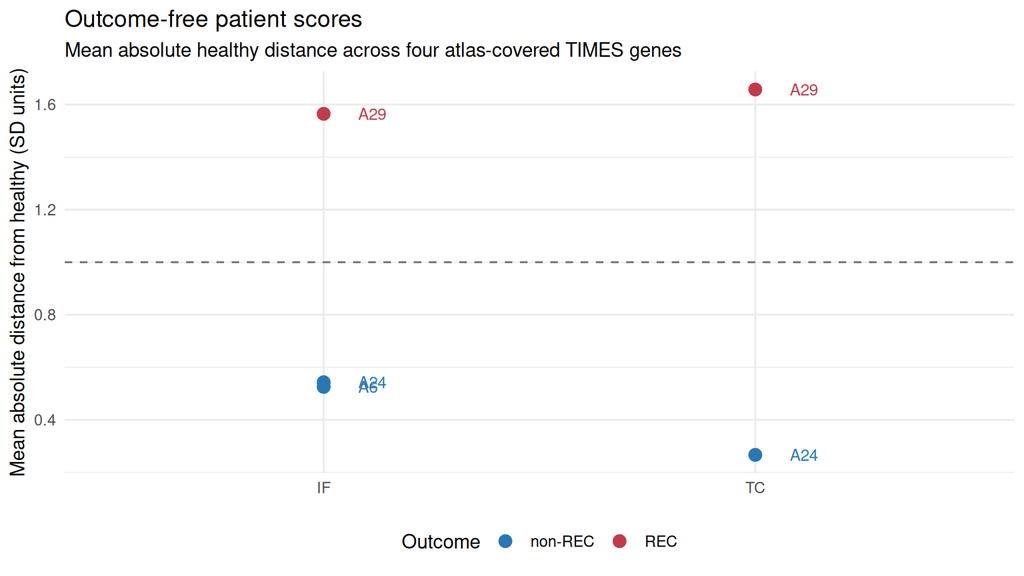

```r
ggplot2::ggplot(
  patient_compartment_proxy,
  ggplot2::aes(
    x = .data$compartment,
    y = .data$healthy_proximity_risk,
    colour = .data$recurrence,
    label = .data$patient_id
  )
) +
  ggplot2::geom_hline(
    yintercept = 1,
    linetype = "dashed",
    colour = "grey45"
  ) +
  ggplot2::geom_point(size = 3) +
  ggplot2::geom_text(
    nudge_x = 0.08,
    hjust = 0,
    size = 3.2,
    show.legend = FALSE
  ) +
  ggplot2::scale_colour_manual(
    values = c(`non-REC` = "#2878B5", REC = "#C23B4A")
  ) +
  ggplot2::labs(
    title = "Outcome-free patient scores",
    subtitle = "Mean absolute healthy distance across four atlas-covered TIMES genes",
    x = NULL,
    y = "Mean absolute distance from healthy (SD units)",
    colour = "Outcome"
  ) +
  ggplot2::theme(legend.position = "bottom")
```

**How to read this patient-level plot.** Each point is one patient in one spatial compartment, rather than a cohort estimate. Its vertical position is the mean of the four gene-specific absolute distances from the healthy liver NK grand mean, measured in healthy-posterior SD units. The score is therefore a reference-deviation index, not a recurrence probability or a model fitted to the recurrence labels. The dashed line at 1 is a descriptive compatibility boundary: a score above it means that the patient’s average biomarker distance exceeds one healthy-reference SD. Outcome colours and labels are added only after the scores have been calculated.

In these data, A29, the only REC patient, lies above the one-SD boundary in both IF and TC, whereas all available non-REC observations lie below it (A6 and A24 nearly overlap in IF). This produces perfect observed patient ordering and a descriptive AUC of 1.0, but it is proof of concept rather than a stable performance estimate because the evaluation contains only three patients and one REC event. The posterior margin plot below carries the baseline and cohort estimation uncertainty that is not displayed by these point estimates.

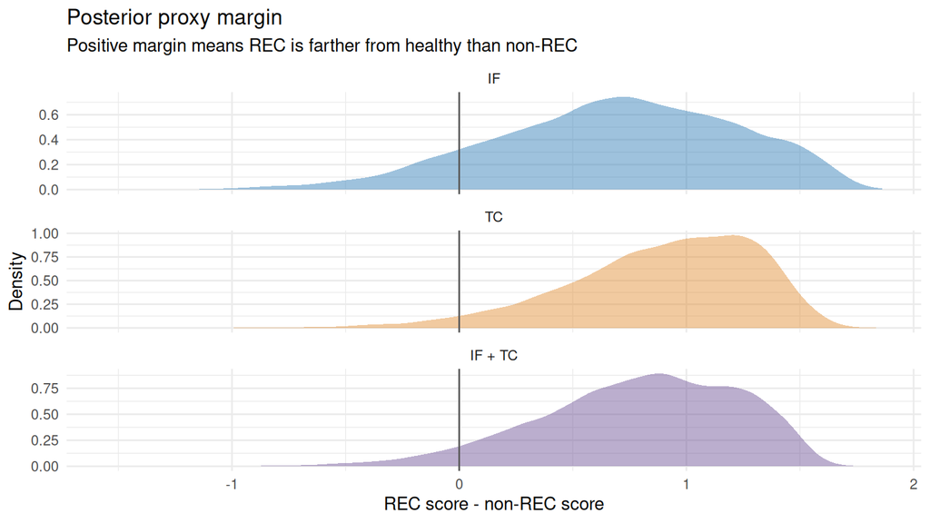

```r
proxy_margin_plot <- dplyr::bind_rows(
  proxy_compartment_draws |>
    dplyr::transmute(
      scope = as.character(.data$compartment),
      margin = .data$margin
    ),
  proxy_combined_draws |>
    dplyr::transmute(
      scope = "IF + TC",
      margin = .data$margin
    )
) |>
  dplyr::mutate(scope = factor(.data$scope, levels = c("IF", "TC", "IF + TC")))

ggplot2::ggplot(
  proxy_margin_plot,
  ggplot2::aes(x = .data$margin, fill = .data$scope)
) +
  ggplot2::geom_density(alpha = 0.45, colour = NA) +
  ggplot2::geom_vline(xintercept = 0, colour = "grey35", linewidth = 0.5) +
  ggplot2::facet_wrap(~ scope, scales = "free_y", ncol = 1) +
  ggplot2::scale_fill_manual(
    values = c(IF = "#2878B5", TC = "#E08A2E", `IF + TC` = "#6A4C93")
  ) +
  ggplot2::labs(
    title = "Posterior proxy margin",
    subtitle = "Positive margin means REC is farther from healthy than non-REC",
    x = "REC score - non-REC score",
    y = "Density",
    fill = NULL
  ) +
  ggplot2::theme(legend.position = "none")
```

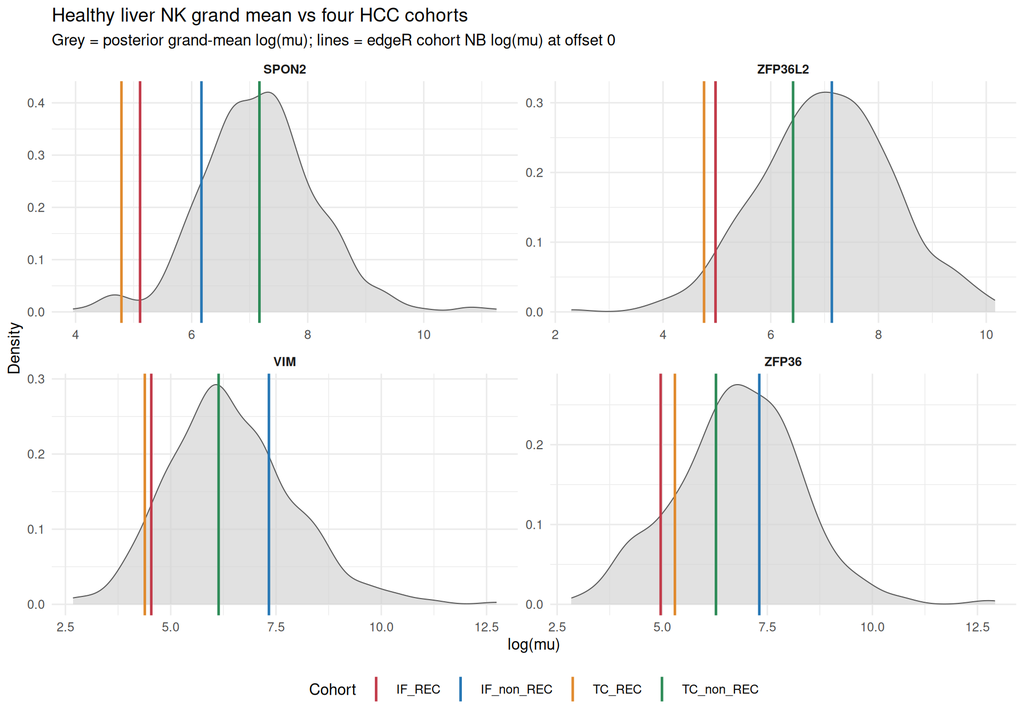

```r
gene_order <- cohort_tests |>
  dplyr::group_by(.data$gene) |>
  dplyr::summarise(
    median_delta = stats::median(.data$delta_log_mu_vs_baseline),
    .groups = "drop"
  ) |>
  dplyr::arrange(.data$median_delta) |>
  dplyr::pull(.data$gene)

cohort_colours <- c(
  IF_REC = "#C23B4A",
  IF_non_REC = "#2878B5",
  TC_REC = "#E08A2E",
  TC_non_REC = "#2D8B57"
)

ggplot2::ggplot() +
  ggplot2::geom_density(
    data = baseline_draws |>
      dplyr::mutate(gene = factor(.data$gene, levels = gene_order)),
    ggplot2::aes(x = .data$baseline_log_mu),
    fill = "grey82",
    colour = "grey35",
    alpha = 0.65,
    linewidth = 0.35
  ) +
  ggplot2::geom_vline(
    data = cohort_tests |>
      dplyr::mutate(gene = factor(.data$gene, levels = gene_order)),
    ggplot2::aes(
      xintercept = .data$cohort_log_mu,
      colour = .data$cohort
    ),
    linewidth = 0.85
  ) +
  ggplot2::scale_colour_manual(values = cohort_colours) +
  ggplot2::facet_wrap(~ gene, scales = "free", ncol = 2) +
  ggplot2::labs(
    title = "Healthy liver NK grand mean vs four HCC cohorts",
    subtitle = "Grey = posterior grand-mean log(mu); lines = edgeR cohort NB log(mu) at offset 0",
    x = "log(mu)",
    y = "Density",
    colour = "Cohort"
  ) +
  ggplot2::theme(
    legend.position = "bottom",
    strip.text = ggplot2::element_text(face = "bold")
  )
```

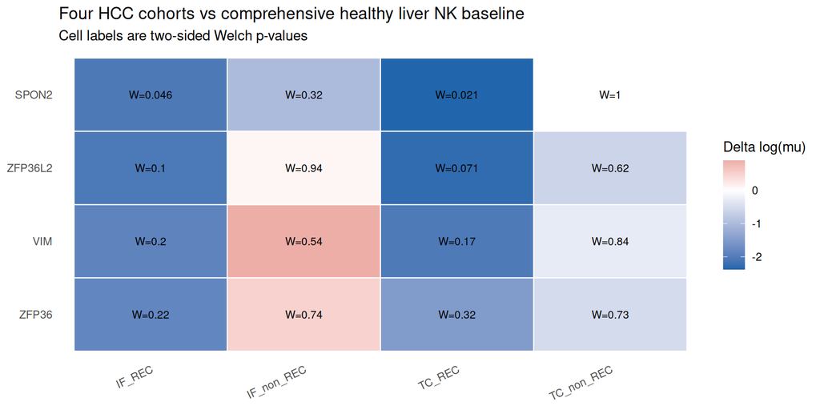

```r
ggplot2::ggplot(
  cohort_tests,
  ggplot2::aes(
    x = .data$cohort,
    y = forcats::fct_rev(factor(.data$gene, levels = gene_order)),
    fill = .data$delta_log_mu_vs_baseline
  )
) +
  ggplot2::geom_tile(colour = "white", linewidth = 0.4) +
  ggplot2::geom_text(
    ggplot2::aes(label = sprintf("W=%.2g", .data$welch_p)),
    size = 3
  ) +
  ggplot2::scale_fill_gradient2(
    low = "#2166AC",
    mid = "white",
    high = "#B2182B",
    midpoint = 0,
    name = "Delta log(mu)"
  ) +
  ggplot2::labs(
    title = "Four HCC cohorts vs comprehensive healthy liver NK baseline",
    subtitle = "Cell labels are two-sided Welch p-values",
    x = NULL,
    y = NULL
  ) +
  ggplot2::theme(
    panel.grid = ggplot2::element_blank(),
    axis.text.x = ggplot2::element_text(angle = 25, hjust = 1)
  )
```

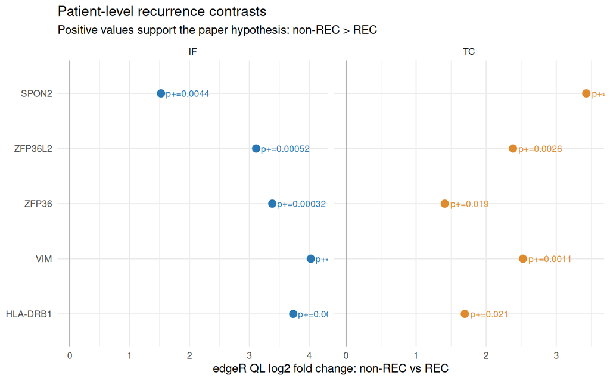

```r
ggplot2::ggplot(
  recurrence_tests,
  ggplot2::aes(
    x = .data$qlf_log2fc_nonrec_vs_rec,
    y = forcats::fct_rev(factor(.data$gene, levels = times_biomarkers$gene)),
    colour = .data$compartment
  )
) +
  ggplot2::geom_vline(xintercept = 0, colour = "grey55", linewidth = 0.4) +
  ggplot2::geom_point(size = 3) +
  ggplot2::geom_text(
    ggplot2::aes(label = sprintf("p+=%.2g", .data$p_nonrec_greater)),
    nudge_x = 0.08,
    hjust = 0,
    size = 3,
    show.legend = FALSE
  ) +
  ggplot2::facet_wrap(~ compartment, scales = "free_x") +
  ggplot2::scale_colour_manual(values = c(IF = "#2878B5", TC = "#E08A2E")) +
  ggplot2::labs(
    title = "Patient-level recurrence contrasts",
    subtitle = "Positive values support the paper hypothesis: non-REC > REC",
    x = "edgeR QL log2 fold change: non-REC vs REC",
    y = NULL,
    colour = "Compartment"
  ) +
  ggplot2::theme(legend.position = "none")
```

# Proxy evaluation, positive control and paper benchmark

```r
proxy_gene_evaluation <- healthy_proxy_gene |>
  dplyr::left_join(
    proxy_gene_posterior_summary |>
      dplyr::select(
        gene, compartment,
        posterior_prob_rec_farther
      ),
    by = c("gene", "compartment")
  )

ground_truth_comparison <- dplyr::bind_rows(
  proxy_gene_evaluation |>
    dplyr::transmute(
      evidence_role = "primary_posteriorHCA_proxy",
      comparison_kind = "healthy_proximity_rec_vs_nonrec",
      gene = .data$gene,
      cohort = NA_character_,
      compartment = .data$compartment,
      expected_direction = "REC farther from healthy",
      observed_direction = dplyr::if_else(
        .data$rec_farther_from_healthy,
        "REC farther from healthy",
        "non-REC farther from healthy"
      ),
      matches_ground_truth = .data$rec_farther_from_healthy,
      observed_metric = .data$proxy_margin_rec_minus_nonrec,
      p_value = 1 - .data$posterior_prob_rec_farther,
      note = paste(
        "Outcome-free proxy hypothesis.",
        "p_value is posterior tail probability P(REC not farther)."
      )
    ),
  proxy_compartment_summary |>
    dplyr::transmute(
      evidence_role = "primary_posteriorHCA_proxy",
      comparison_kind = "healthy_proximity_rec_vs_nonrec",
      gene = "four_gene_mean",
      cohort = NA_character_,
      compartment = .data$compartment,
      expected_direction = "REC farther from healthy",
      observed_direction = dplyr::if_else(
        .data$mean_margin > 0,
        "REC farther from healthy",
        "non-REC farther from healthy"
      ),
      matches_ground_truth = .data$mean_margin > 0,
      observed_metric = .data$mean_margin,
      p_value = 1 - .data$posterior_prob_rec_farther,
      note = "Mean healthy-distance proxy across four atlas-covered TIMES genes."
    ),
  proxy_combined_summary |>
    dplyr::transmute(
      evidence_role = "primary_posteriorHCA_proxy",
      comparison_kind = "healthy_proximity_rec_vs_nonrec",
      gene = "four_gene_mean",
      cohort = NA_character_,
      compartment = "IF_TC_combined",
      expected_direction = "REC farther from healthy",
      observed_direction = dplyr::if_else(
        .data$mean_margin > 0,
        "REC farther from healthy",
        "non-REC farther from healthy"
      ),
      matches_ground_truth = .data$mean_margin > 0,
      observed_metric = .data$mean_margin,
      p_value = 1 - .data$posterior_prob_rec_farther,
      note = "Combined IF+TC posteriorHCA healthy-proximity proxy."
    ),
  recurrence_tests |>
    dplyr::transmute(
      evidence_role = "positive_control_paper_direction",
      comparison_kind = "recurrence_direction",
      gene = .data$gene,
      cohort = NA_character_,
      compartment = .data$compartment,
      expected_direction = .data$expected_recurrence_direction,
      observed_direction = .data$observed_recurrence_direction,
      matches_ground_truth = .data$recurrence_matches_paper,
      observed_metric = .data$qlf_log2fc_nonrec_vs_rec,
      p_value = .data$p_nonrec_greater,
      note = "Direct comparison with paper direction; positive metric means non-REC > REC."
    )
)

readr::write_csv(ground_truth_comparison, params$ground_truth_comparison_csv)

ground_truth_comparison |>
  dplyr::mutate(dplyr::across(dplyr::where(is.numeric), ~round(.x, 4)))
```

| evidence_role | comparison_kind | gene | cohort | compartment | expected_direction | observed_direction | matches_ground_truth | observed_metric | p_value | note |
| --- | --- | --- | --- | --- | --- | --- | --- | --- | --- | --- |
| primary_posteriorHCA_proxy | healthy_proximity_rec_vs_nonrec | SPON2 | NA | IF | REC farther from healthy | REC farther from healthy | TRUE | 1.0538 | 0.0450 | Outcome-free proxy hypothesis. p_value is posterior tail probability P(REC not farther). |
| primary_posteriorHCA_proxy | healthy_proximity_rec_vs_nonrec | SPON2 | NA | TC | REC farther from healthy | REC farther from healthy | TRUE | 2.3693 | 0.0987 | Outcome-free proxy hypothesis. p_value is posterior tail probability P(REC not farther). |
| primary_posteriorHCA_proxy | healthy_proximity_rec_vs_nonrec | VIM | NA | IF | REC farther from healthy | REC farther from healthy | TRUE | 0.6738 | 0.3855 | Outcome-free proxy hypothesis. p_value is posterior tail probability P(REC not farther). |
| primary_posteriorHCA_proxy | healthy_proximity_rec_vs_nonrec | VIM | NA | TC | REC farther from healthy | REC farther from healthy | TRUE | 1.1881 | 0.2140 | Outcome-free proxy hypothesis. p_value is posterior tail probability P(REC not farther). |
| primary_posteriorHCA_proxy | healthy_proximity_rec_vs_nonrec | ZFP36 | NA | IF | REC farther from healthy | REC farther from healthy | TRUE | 0.9002 | 0.3030 | Outcome-free proxy hypothesis. p_value is posterior tail probability P(REC not farther). |
| primary_posteriorHCA_proxy | healthy_proximity_rec_vs_nonrec | ZFP36 | NA | TC | REC farther from healthy | REC farther from healthy | TRUE | 0.6555 | 0.2350 | Outcome-free proxy hypothesis. p_value is posterior tail probability P(REC not farther). |
| primary_posteriorHCA_proxy | healthy_proximity_rec_vs_nonrec | ZFP36L2 | NA | IF | REC farther from healthy | REC farther from healthy | TRUE | 1.6068 | 0.2109 | Outcome-free proxy hypothesis. p_value is posterior tail probability P(REC not farther). |
| primary_posteriorHCA_proxy | healthy_proximity_rec_vs_nonrec | ZFP36L2 | NA | TC | REC farther from healthy | REC farther from healthy | TRUE | 1.3498 | 0.1244 | Outcome-free proxy hypothesis. p_value is posterior tail probability P(REC not farther). |
| primary_posteriorHCA_proxy | healthy_proximity_rec_vs_nonrec | four_gene_mean | NA | IF | REC farther from healthy | REC farther from healthy | TRUE | 0.6903 | 0.1097 | Mean healthy-distance proxy across four atlas-covered TIMES genes. |
| primary_posteriorHCA_proxy | healthy_proximity_rec_vs_nonrec | four_gene_mean | NA | TC | REC farther from healthy | REC farther from healthy | TRUE | 0.8914 | 0.0328 | Mean healthy-distance proxy across four atlas-covered TIMES genes. |

[output cut: 11 more lines]

# Interpretation and remaining limitation

The direct edgeR contrast remains a positive control: all five paper biomarkers retain the published `non-REC > REC` direction in IF and TC. The supplied TIMES validation-score subset has descriptive AUC = 0.75, compared with the proxy’s AUC above. This is not an equivalence test: the paper benchmark uses mIHC scores from 11 patients, whereas the posteriorHCA proxy currently has only three GeoMx patients and four atlas-covered genes.

The public cohort is extremely small after patient-level aggregation, so the perfect patient ordering is proof of concept, not proof of equal power. The exact rank p-value remains weak because there is one REC patient. The stronger evidence here is the pre-specified reference pattern, its 8/8 consistency, the combined posterior probability, and leave-one-gene-out stability. The paper’s much smaller gene-level p-values used multiple GeoMx ROI segments and adjusted for age/sex where possible; this report protects the patient as the independent unit and avoids ROI pseudoreplication.

For final publication-grade calibration, rerun this identical workflow with the controlled-access raw GeoMx count matrices. `HLA-DRB1` remains testable for the within-HCC recurrence contrast when present in the merged count fit, but it has no comprehensive-baseline result while its `V1_nk` brms model branch is absent.

```r
output_paths <- c(
  baseline_draws_rds = params$baseline_draws_rds,
  paper_ground_truth_csv = params$paper_ground_truth_csv,
  cohort_results_csv = params$cohort_results_csv,
  recurrence_results_csv = params$recurrence_results_csv,
  patient_pseudobulk_csv = params$patient_pseudobulk_csv,
  normalization_csv = params$normalization_csv,
  ground_truth_comparison_csv = params$ground_truth_comparison_csv,
  healthy_proxy_gene_csv = params$healthy_proxy_gene_csv,
  healthy_proxy_summary_csv = params$healthy_proxy_summary_csv,
  healthy_proxy_patient_csv = params$healthy_proxy_patient_csv,
  healthy_proxy_performance_csv = params$healthy_proxy_performance_csv,
  paper_benchmark_csv = params$paper_benchmark_csv
)

tibble::tibble(
  output = names(output_paths),
  path = unname(output_paths),
  exists = file.exists(output_paths)
)
```

| output | path | exists |
| --- | --- | --- |
| baseline_draws_rds | /home/a1237163/lab/chen/posteriorHCA/dev/Jie_HCC/data/processed/Jie_HCC_V1_nk_comprehensive_liver_baseline_log_mu_draws.rds | TRUE |
| paper_ground_truth_csv | /home/a1237163/lab/chen/posteriorHCA/dev/Jie_HCC/data/processed/Jie_HCC_paper_ground_truth_TIMES_biomarkers.csv | TRUE |
| cohort_results_csv | /home/a1237163/lab/chen/posteriorHCA/dev/Jie_HCC/data/processed/Jie_HCC_four_cohort_comprehensive_liver_baseline_mu_tests.csv | TRUE |
| recurrence_results_csv | /home/a1237163/lab/chen/posteriorHCA/dev/Jie_HCC/data/processed/Jie_HCC_IF_TC_nonREC_vs_REC_edger_tests.csv | TRUE |
| patient_pseudobulk_csv | /home/a1237163/lab/chen/posteriorHCA/dev/Jie_HCC/data/processed/Jie_HCC_IF_TC_patient_pseudobulk_metadata.csv | TRUE |
| normalization_csv | /home/a1237163/lab/chen/posteriorHCA/dev/Jie_HCC/data/processed/Jie_HCC_IF_TC_TMMwsp_offsets.csv | TRUE |
| ground_truth_comparison_csv | /home/a1237163/lab/chen/posteriorHCA/dev/Jie_HCC/data/processed/Jie_HCC_TIMES_recurrence_ground_truth_and_healthy_context.csv | TRUE |
| healthy_proxy_gene_csv | /home/a1237163/lab/chen/posteriorHCA/dev/Jie_HCC/data/processed/Jie_HCC_healthy_proximity_proxy_gene_compartment.csv | TRUE |
| healthy_proxy_summary_csv | /home/a1237163/lab/chen/posteriorHCA/dev/Jie_HCC/data/processed/Jie_HCC_healthy_proximity_proxy_posterior_summary.csv | TRUE |
| healthy_proxy_patient_csv | /home/a1237163/lab/chen/posteriorHCA/dev/Jie_HCC/data/processed/Jie_HCC_healthy_proximity_proxy_patient_scores.csv | TRUE |

[output cut: 2 more lines]